# Homework 2

Benas rolled two six-sided die and plotted their values on the histogram below. What percentage of the rolls were either a 6, 7, or 8?

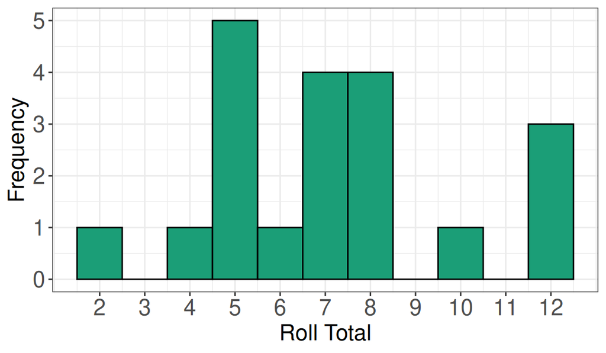

**Answer:** 45

**Solution:**

Each bar shows the number of times a certain value was rolled. Therefore the total percentage of rolls for 6, 7, and 8 is . . .

$\frac{1 + 4 + 4}{1 + 1 + 5 + 1 + 4 + 4 + 1 + 3} \times 100 = \frac{9}{20} \times 100 = 45$

**R Code:**

```
freq_678 <- c(1, 4, 4)
freq_tot <- c(1, 1, 5, 1, 4, 4, 1, 3)

sum(freq_678) / sum(freq_tot) * 100
```

Zane rolled two six-sided die and plotted their values on the histogram below. What percentage of the rolls were either a 6, 7, or 8?

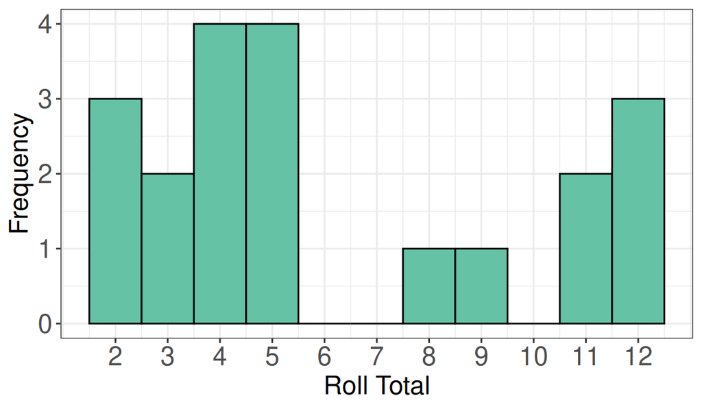

**Answer:** 5

**Solution:**

Each bar shows the number of times a certain value was rolled. Therefore the total percentage of rolls for 6, 7, and 8 is . . .

$\frac{1}{3 + 2 + 4 + 4 + 1 + 1 + 2 + 3} \times 100 = \frac{1}{20} \times 100 = 5$

**R Code:**

```
freq_678 <- c(1)
freq_tot <- c(3, 2, 4, 4, 1, 1, 2, 3)

sum(freq_678) / sum(freq_tot) * 100
```

Emily rolled two six-sided die and plotted their values on the histogram below. What percentage of the rolls were either a 6, 7, or 8?

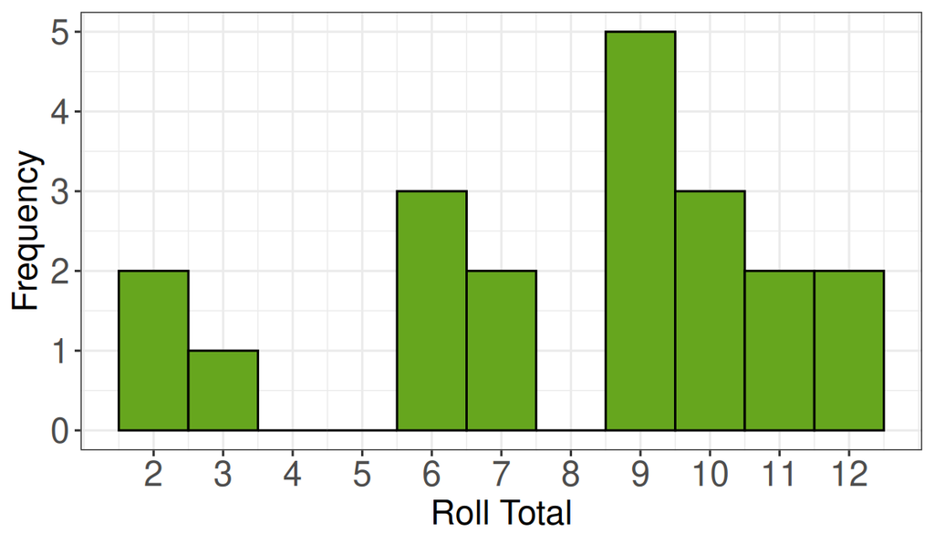

**Answer:** 25

**Solution:**

Each bar shows the number of times a certain value was rolled. Therefore the total percentage of rolls for 6, 7, and 8 is . . .

$\frac{3 + 2}{2 + 1 + 3 + 2 + 5 + 3 + 2 + 2} \times 100 = \frac{5}{20} \times 100 = 25$

**R Code:**

```
freq_678 <- c(3, 2)
freq_tot <- c(2, 1, 3, 2, 5, 3, 2, 2)

sum(freq_678) / sum(freq_tot) * 100
```

David rolled two six-sided die and plotted their values on the histogram below. What percentage of the rolls were either a 6, 7, or 8?

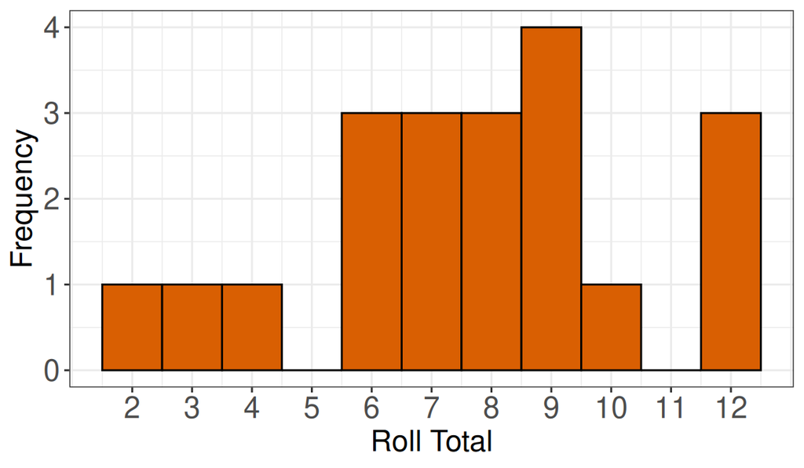

**Answer:** 45

**Solution:**

Each bar shows the number of times a certain value was rolled. Therefore the total percentage of rolls for 6, 7, and 8 is . . .

$\frac{3 + 3 + 3}{1 + 1 + 1 + 3 + 3 + 3 + 4 + 1 + 3} \times 100 = \frac{9}{20} \times 100 = 45$

**R Code:**

```
freq_678 <- c(3, 3, 3)
freq_tot <- c(1, 1, 1, 3, 3, 3, 4, 1, 3)

sum(freq_678) / sum(freq_tot) * 100
```

Nykola rolled two six-sided die and plotted their values on the histogram below. What percentage of the rolls were either a 6, 7, or 8?

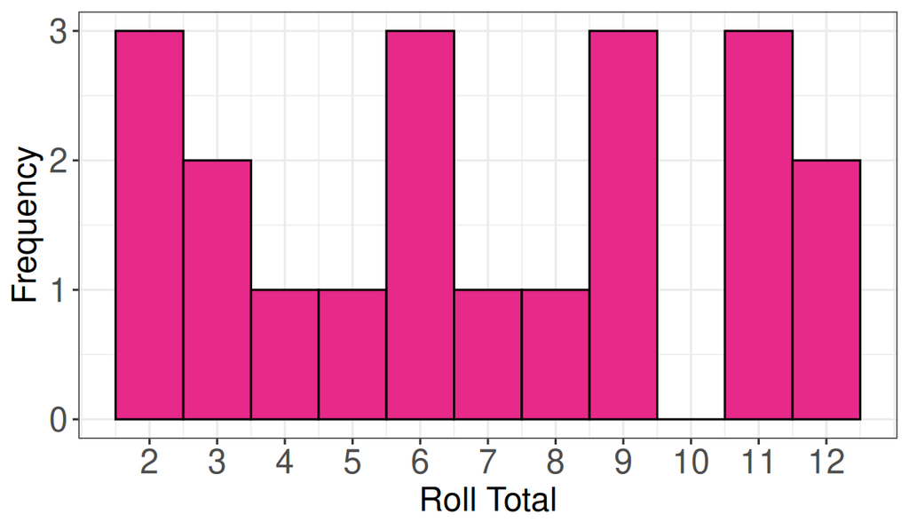

**Answer:** 25

**Solution:**

Each bar shows the number of times a certain value was rolled. Therefore the total percentage of rolls for 6, 7, and 8 is . . .

$\frac{3 + 1 + 1}{3 + 2 + 1 + 1 + 3 + 1 + 1 + 3 + 3 + 2} \times 100 = \frac{5}{20} \times 100 = 25$

**R Code:**

```
freq_678 <- c(3, 1, 1)
freq_tot <- c(3, 2, 1, 1, 3, 1, 1, 3, 3, 2)

sum(freq_678) / sum(freq_tot) * 100
```

Dominique rolled two six-sided die and plotted their values on the histogram below. What percentage of the rolls were either a 6, 7, or 8?

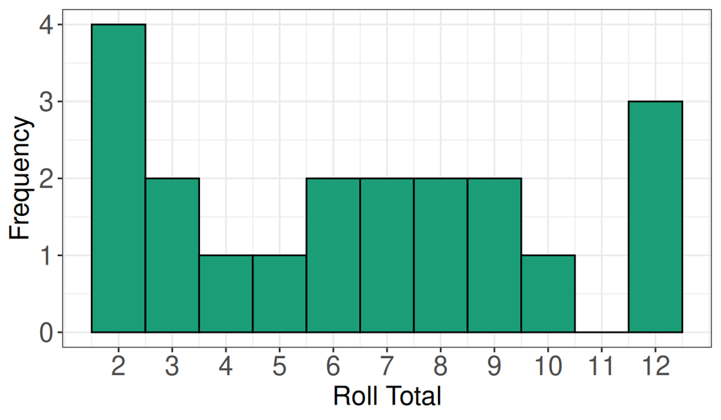

**Answer:** 30

**Solution:**

Each bar shows the number of times a certain value was rolled. Therefore the total percentage of rolls for 6, 7, and 8 is . . .

$\frac{2 + 2 + 2}{4 + 2 + 1 + 1 + 2 + 2 + 2 + 2 + 1 + 3} \times 100 = \frac{6}{20} \times 100 = 30$

**R Code:**

```
freq_678 <- c(2, 2, 2)
freq_tot <- c(4, 2, 1, 1, 2, 2, 2, 2, 1, 3)

sum(freq_678) / sum(freq_tot) * 100
```

Nicholas rolled two six-sided die and plotted their values on the histogram below. What percentage of the rolls were either a 6, 7, or 8?

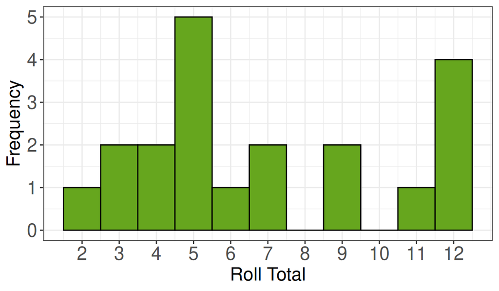

**Answer:** 15

**Solution:**

Each bar shows the number of times a certain value was rolled. Therefore the total percentage of rolls for 6, 7, and 8 is . . .

$\frac{1 + 2}{1 + 2 + 2 + 5 + 1 + 2 + 2 + 1 + 4} \times 100 = \frac{3}{20} \times 100 = 15$

**R Code:**

```
freq_678 <- c(1, 2)
freq_tot <- c(1, 2, 2, 5, 1, 2, 2, 1, 4)

sum(freq_678) / sum(freq_tot) * 100
```

Mitchell rolled two six-sided die and plotted their values on the histogram below. What percentage of the rolls were either a 6, 7, or 8?

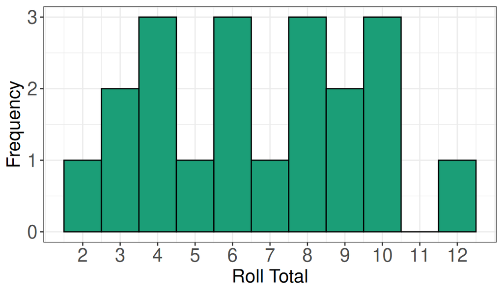

**Answer:** 35

**Solution:**

Each bar shows the number of times a certain value was rolled. Therefore the total percentage of rolls for 6, 7, and 8 is . . .

$\frac{3 + 1 + 3}{1 + 2 + 3 + 1 + 3 + 1 + 3 + 2 + 3 + 1} \times 100 = \frac{7}{20} \times 100 = 35$

**R Code:**

```
freq_678 <- c(3, 1, 3)
freq_tot <- c(1, 2, 3, 1, 3, 1, 3, 2, 3, 1)

sum(freq_678) / sum(freq_tot) * 100
```

Madison rolled two six-sided die and plotted their values on the histogram below. What percentage of the rolls were either a 6, 7, or 8?

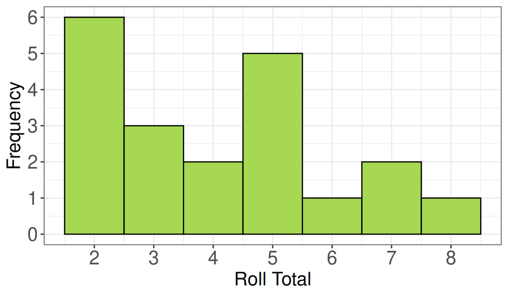

**Answer:** 20

**Solution:**

Each bar shows the number of times a certain value was rolled. Therefore the total percentage of rolls for 6, 7, and 8 is . . .

$\frac{1 + 2 + 1}{6 + 3 + 2 + 5 + 1 + 2 + 1} \times 100 = \frac{4}{20} \times 100 = 20$

**R Code:**

```
freq_678 <- c(1, 2, 1)
freq_tot <- c(6, 3, 2, 5, 1, 2, 1)

sum(freq_678) / sum(freq_tot) * 100
```

Robert rolled two six-sided die and plotted their values on the histogram below. What percentage of the rolls were either a 6, 7, or 8?

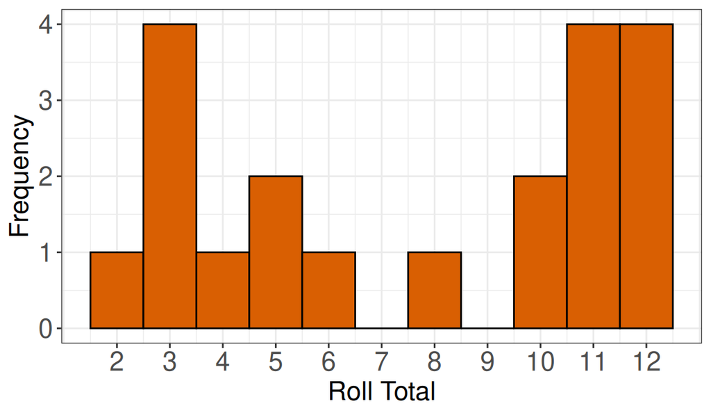

**Answer:** 10

**Solution:**

Each bar shows the number of times a certain value was rolled. Therefore the total percentage of rolls for 6, 7, and 8 is . . .

$\frac{1 + 1}{1 + 4 + 1 + 2 + 1 + 1 + 2 + 4 + 4} \times 100 = \frac{2}{20} \times 100 = 10$

**R Code:**

```
freq_678 <- c(1, 1)
freq_tot <- c(1, 4, 1, 2, 1, 1, 2, 4, 4)

sum(freq_678) / sum(freq_tot) * 100
```

The mean of two numbers is 549.5, and one number is 491 more than the other. What is the value of the smaller of the two numbers?

**Answer:** 304

**Solution:**

We can solve this with some basic algebra where $x$ is the smaller of the two numbers:

$\frac{x + (x + 491)}{2} = 549.5$

$\frac{2x + 491}{2} = 549.5$

$2x + 491 = 549.5 \times 2$

$2x = (549.5 \times 2) - 491$

$x = \frac{(549.5 \times 2) - 491}{2}$

$x = 304$

The mean of two numbers is 248.5, and one number is 39 more than the other. What is the value of the smaller of the two numbers?

**Answer:** 229

**Solution:**

We can solve this with some basic algebra where $x$ is the smaller of the two numbers:

$\frac{x + (x + 39)}{2} = 248.5$

$\frac{2x + 39}{2} = 248.5$

$2x + 39 = 248.5 \times 2$

$2x = (248.5 \times 2) - 39$

$x = \frac{(248.5 \times 2) - 39}{2}$

$x = 229$

The mean of two numbers is 551.5, and one number is 467 more than the other. What is the value of the smaller of the two numbers?

**Answer:** 318

**Solution:**

We can solve this with some basic algebra where $x$ is the smaller of the two numbers:

$\frac{x + (x + 467)}{2} = 551.5$

$\frac{2x + 467}{2} = 551.5$

$2x + 467 = 551.5 \times 2$

$2x = (551.5 \times 2) - 467$

$x = \frac{(551.5 \times 2) - 467}{2}$

$x = 318$

The mean of two numbers is 608, and one number is 226 more than the other. What is the value of the smaller of the two numbers?

**Answer:** 495

**Solution:**

We can solve this with some basic algebra where $x$ is the smaller of the two numbers:

$\frac{x + (x + 226)}{2} = 608$

$\frac{2x + 226}{2} = 608$

$2x + 226 = 608 \times 2$

$2x = (608 \times 2) - 226$

$x = \frac{(608 \times 2) - 226}{2}$

$x = 495$

The mean of two numbers is 371, and one number is 310 more than the other. What is the value of the smaller of the two numbers?

**Answer:** 216

**Solution:**

We can solve this with some basic algebra where $x$ is the smaller of the two numbers:

$\frac{x + (x + 310)}{2} = 371$

$\frac{2x + 310}{2} = 371$

$2x + 310 = 371 \times 2$

$2x = (371 \times 2) - 310$

$x = \frac{(371 \times 2) - 310}{2}$

$x = 216$

The mean of two numbers is 797, and one number is 6 more than the other. What is the value of the smaller of the two numbers?

**Answer:** 794

**Solution:**

We can solve this with some basic algebra where $x$ is the smaller of the two numbers:

$\frac{x + (x + 6)}{2} = 797$

$\frac{2x + 6}{2} = 797$

$2x + 6 = 797 \times 2$

$2x = (797 \times 2) - 6$

$x = \frac{(797 \times 2) - 6}{2}$

$x = 794$

The mean of two numbers is 466, and one number is 786 more than the other. What is the value of the smaller of the two numbers?

**Answer:** 73

**Solution:**

We can solve this with some basic algebra where $x$ is the smaller of the two numbers:

$\frac{x + (x + 786)}{2} = 466$

$\frac{2x + 786}{2} = 466$

$2x + 786 = 466 \times 2$

$2x = (466 \times 2) - 786$

$x = \frac{(466 \times 2) - 786}{2}$

$x = 73$

The mean of two numbers is 440.5, and one number is 381 more than the other. What is the value of the smaller of the two numbers?

**Answer:** 250

**Solution:**

We can solve this with some basic algebra where $x$ is the smaller of the two numbers:

$\frac{x + (x + 381)}{2} = 440.5$

$\frac{2x + 381}{2} = 440.5$

$2x + 381 = 440.5 \times 2$

$2x = (440.5 \times 2) - 381$

$x = \frac{(440.5 \times 2) - 381}{2}$

$x = 250$

The mean of two numbers is 85, and one number is 76 more than the other. What is the value of the smaller of the two numbers?

**Answer:** 47

**Solution:**

We can solve this with some basic algebra where $x$ is the smaller of the two numbers:

$\frac{x + (x + 76)}{2} = 85$

$\frac{2x + 76}{2} = 85$

$2x + 76 = 85 \times 2$

$2x = (85 \times 2) - 76$

$x = \frac{(85 \times 2) - 76}{2}$

$x = 47$

The mean of two numbers is 118.5, and one number is 105 more than the other. What is the value of the smaller of the two numbers?

**Answer:** 66

**Solution:**

We can solve this with some basic algebra where $x$ is the smaller of the two numbers:

$\frac{x + (x + 105)}{2} = 118.5$

$\frac{2x + 105}{2} = 118.5$

$2x + 105 = 118.5 \times 2$

$2x = (118.5 \times 2) - 105$

$x = \frac{(118.5 \times 2) - 105}{2}$

$x = 66$

Compute the second quartile of this data:

27.4, 26.5, 21.5, 28.9, 21, 28.1, 24.8, 29.3, 33, 21.9, 20.4, 31.6, 21, 30, 26.4, 21, 25

**Answer:** 26.4

**R code:**

```
x <- c(27.4, 26.5, 21.5, 28.9, 21, 28.1, 24.8, 29.3, 33, 21.9, 20.4, 31.6, 21, 30, 26.4, 21, 25)

median(x) # remember that Q2 = median.
```

Compute the second quartile of this data:

22.3, 30.4, 23.7, 22.2, 29.6, 18.5, 25.6, 24.1, 26.7, 33.9, 23, 32.7, 22.6, 20.1, 31.5, 24.9, 23

**Answer:** 24.1

**R code:**

```
x <- c(22.3, 30.4, 23.7, 22.2, 29.6, 18.5, 25.6, 24.1, 26.7, 33.9, 23, 32.7, 22.6, 20.1, 31.5, 24.9, 23)

median(x) # remember that Q2 = median.
```

Compute the second quartile of this data:

25.9, 26.2, 23.6, 24.6, 22.8, 24, 27, 21.5, 11.8, 27.1, 26.1, 24.1, 32, 23, 19.9, 28.3, 29.4, 19.1, 24.9

**Answer:** 24.6

**R code:**

```
x <- c(25.9, 26.2, 23.6, 24.6, 22.8, 24, 27, 21.5, 11.8, 27.1, 26.1, 24.1, 32, 23, 19.9, 28.3, 29.4, 19.1, 24.9)

median(x) # remember that Q2 = median.
```

Compute the second quartile of this data:

25.3, 19.4, 13.6, 21.8, 27.7, 16.7, 24.9, 26.1, 27.2, 15.7, 25.1, 18.9, 32.8, 29.6, 24.7, 12.8

**Answer:** 24.8

**R code:**

```
x <- c(25.3, 19.4, 13.6, 21.8, 27.7, 16.7, 24.9, 26.1, 27.2, 15.7, 25.1, 18.9, 32.8, 29.6, 24.7, 12.8)

median(x) # remember that Q2 = median.
```

Compute the second quartile of this data:

25.3, 23.2, 23.6, 23.7, 28.2, 23.3, 32.2, 24.2, 28.8, 27.8, 23.6, 26.4, 25.7, 23, 33.7, 25.6, 25.8, 24.5, 25.1, 21.9

**Answer:** 25.2

**R code:**

```
x <- c(25.3, 23.2, 23.6, 23.7, 28.2, 23.3, 32.2, 24.2, 28.8, 27.8, 23.6, 26.4, 25.7, 23, 33.7, 25.6, 25.8, 24.5, 25.1, 21.9)

median(x) # remember that Q2 = median.
```

Compute the second quartile of this data:

28.9, 31.3, 29.6, 31.8, 29, 26.9, 36.2, 19.3, 23, 30.9, 25.3, 27.7, 22.6, 25.7, 23.5, 24.7, 26.8, 31, 21.9

**Answer:** 26.9

**R code:**

```
x <- c(28.9, 31.3, 29.6, 31.8, 29, 26.9, 36.2, 19.3, 23, 30.9, 25.3, 27.7, 22.6, 25.7, 23.5, 24.7, 26.8, 31, 21.9)

median(x) # remember that Q2 = median.
```

Compute the second quartile of this data:

16.6, 26.1, 23.4, 29.5, 22, 27.3, 25.1, 22.1, 27.1, 27.8, 24.9, 28.4, 21.6, 17.4, 27.3, 29.1, 22.7, 30.7

**Answer:** 25.6

**R code:**

```
x <- c(16.6, 26.1, 23.4, 29.5, 22, 27.3, 25.1, 22.1, 27.1, 27.8, 24.9, 28.4, 21.6, 17.4, 27.3, 29.1, 22.7, 30.7)

median(x) # remember that Q2 = median.
```

Compute the second quartile of this data:

20.6, 26.2, 22.9, 25.5, 28.3, 23.7, 28, 25.4, 18.3, 25.7, 20.6, 25.6, 23.6, 18.9, 31.2

**Answer:** 25.4

**R code:**

```
x <- c(20.6, 26.2, 22.9, 25.5, 28.3, 23.7, 28, 25.4, 18.3, 25.7, 20.6, 25.6, 23.6, 18.9, 31.2)

median(x) # remember that Q2 = median.
```

Compute the second quartile of this data:

24.6, 26.1, 19.7, 25.6, 32.8, 29.1, 23.2, 30.6, 27.8, 24.4, 22.6, 25.7, 20.6, 31.4, 31.1, 25.9, 27.8

**Answer:** 25.9

**R code:**

```
x <- c(24.6, 26.1, 19.7, 25.6, 32.8, 29.1, 23.2, 30.6, 27.8, 24.4, 22.6, 25.7, 20.6, 31.4, 31.1, 25.9, 27.8)

median(x) # remember that Q2 = median.
```

Compute the second quartile of this data:

28.8, 25.1, 31.4, 29.3, 25.9, 30, 30.1, 18.2, 19.7, 23.4, 25.2, 23.8, 26.7, 27.7, 27.5, 20.8, 28.1, 21.8, 23.6, 27.2

**Answer:** 26.3

**R code:**

```
x <- c(28.8, 25.1, 31.4, 29.3, 25.9, 30, 30.1, 18.2, 19.7, 23.4, 25.2, 23.8, 26.7, 27.7, 27.5, 20.8, 28.1, 21.8, 23.6, 27.2)

median(x) # remember that Q2 = median.
```

Suppose a psychologist, studying the impact of environmental factors on development, monitors a group of children in a local community center. The psychologist collected the test scores of 32 different children in the center. They obtained the following values:

20.5, 23.2, 28.9, 19.8, 21.9, 21.2, 23.9, 24.9, 24.9, 26.1, 29.5, 22.2, 30.4, 31.2, 21, 20.3, 22.6, 29.1, 27, 30.3, 20.2, 27.1, 22.5, 23.9, 23, 17.8, 26.7, 25.3, 21.4, 23.9, 23.3, 18.7

Compute the first quartile of the data set.

**Answer:** 21.35

**R code:**

```
x <- c(20.5, 23.2, 28.9, 19.8, 21.9, 21.2, 23.9, 24.9, 24.9, 26.1, 29.5, 22.2, 30.4, 31.2, 21, 20.3, 22.6, 29.1, 27, 30.3, 20.2, 27.1, 22.5, 23.9, 23, 17.8, 26.7, 25.3, 21.4, 23.9, 23.3, 18.7)

quantile(x)[2]
```

Suppose a psychologist, studying the impact of environmental factors on development, monitors a group of children in a local community center. The psychologist collected the test scores of 30 different children in the center. They obtained the following values:

21.1, 21.8, 27.7, 20.9, 26.2, 24.2, 31.1, 26.6, 26.5, 22.1, 24.9, 17.6, 25, 23.9, 27, 19.6, 23.8, 29.7, 18.4, 24.7, 22.5, 24.5, 15.6, 28.6, 26.8, 28.3, 23.9, 23.6, 31.1, 19.6

Compute the first quartile of the data set.

**Answer:** 21.875

**R code:**

```
x <- c(21.1, 21.8, 27.7, 20.9, 26.2, 24.2, 31.1, 26.6, 26.5, 22.1, 24.9, 17.6, 25, 23.9, 27, 19.6, 23.8, 29.7, 18.4, 24.7, 22.5, 24.5, 15.6, 28.6, 26.8, 28.3, 23.9, 23.6, 31.1, 19.6)

quantile(x)[2]
```

Suppose a psychologist, studying the impact of environmental factors on development, monitors a group of children in a local community center. The psychologist collected the test scores of 34 different children in the center. They obtained the following values:

26.5, 20.4, 23.4, 35.9, 21.1, 26.2, 26.3, 20.3, 27.8, 23.8, 28.4, 30.7, 22.7, 27.3, 27.8, 29.9, 20.7, 27.1, 22.2, 17.7, 26.6, 23.9, 30.5, 28.2, 26.6, 23.1, 26.2, 22.8, 16.8, 33, 24.4, 31.5, 18, 24.2

Compute the first quartile of the data set.

**Answer:** 22.725

**R code:**

```
x <- c(26.5, 20.4, 23.4, 35.9, 21.1, 26.2, 26.3, 20.3, 27.8, 23.8, 28.4, 30.7, 22.7, 27.3, 27.8, 29.9, 20.7, 27.1, 22.2, 17.7, 26.6, 23.9, 30.5, 28.2, 26.6, 23.1, 26.2, 22.8, 16.8, 33, 24.4, 31.5, 18, 24.2)

quantile(x)[2]
```

Suppose a psychologist, studying the impact of environmental factors on development, monitors a group of children in a local community center. The psychologist collected the test scores of 35 different children in the center. They obtained the following values:

17.9, 21.4, 19.6, 29.8, 30.6, 17.1, 29.8, 23.8, 22.8, 22, 21.4, 24.2, 27.8, 20.6, 17.7, 27.2, 25.2, 31.5, 19.7, 28.1, 27.8, 19, 22.9, 27.5, 21.6, 21.6, 24.5, 24.3, 26.4, 25.6, 25.3, 21.4, 24.9, 27.2, 24.8

Compute the first quartile of the data set.

**Answer:** 21.4

**R code:**

```
x <- c(17.9, 21.4, 19.6, 29.8, 30.6, 17.1, 29.8, 23.8, 22.8, 22, 21.4, 24.2, 27.8, 20.6, 17.7, 27.2, 25.2, 31.5, 19.7, 28.1, 27.8, 19, 22.9, 27.5, 21.6, 21.6, 24.5, 24.3, 26.4, 25.6, 25.3, 21.4, 24.9, 27.2, 24.8)

quantile(x)[2]
```

Suppose a psychologist, studying the impact of environmental factors on development, monitors a group of children in a local community center. The psychologist collected the test scores of 32 different children in the center. They obtained the following values:

23.8, 28.4, 20.3, 28, 29.5, 24.6, 30.9, 25.3, 17.3, 27, 26.2, 29.6, 29.6, 25.9, 17.3, 25.2, 21.6, 24.3, 24.5, 31.4, 27.6, 20.5, 23.6, 34.4, 24.4, 32.2, 21.6, 29.4, 21, 26.9, 27.2, 27.7

Compute the first quartile of the data set.

**Answer:** 23.75

**R code:**

```
x <- c(23.8, 28.4, 20.3, 28, 29.5, 24.6, 30.9, 25.3, 17.3, 27, 26.2, 29.6, 29.6, 25.9, 17.3, 25.2, 21.6, 24.3, 24.5, 31.4, 27.6, 20.5, 23.6, 34.4, 24.4, 32.2, 21.6, 29.4, 21, 26.9, 27.2, 27.7)

quantile(x)[2]
```

Suppose a psychologist, studying the impact of environmental factors on development, monitors a group of children in a local community center. The psychologist collected the test scores of 32 different children in the center. They obtained the following values:

22.5, 31.3, 33.5, 25.8, 23.1, 22.5, 22, 25.3, 27.4, 29.8, 17.8, 23.2, 26.2, 23.1, 25.7, 27, 31.9, 17.1, 22.7, 22.2, 26.1, 25.7, 26.4, 25.5, 20.7, 29.4, 18.4, 24.8, 26.7, 30.3, 26.7, 22.1

Compute the first quartile of the data set.

**Answer:** 22.5

**R code:**

```
x <- c(22.5, 31.3, 33.5, 25.8, 23.1, 22.5, 22, 25.3, 27.4, 29.8, 17.8, 23.2, 26.2, 23.1, 25.7, 27, 31.9, 17.1, 22.7, 22.2, 26.1, 25.7, 26.4, 25.5, 20.7, 29.4, 18.4, 24.8, 26.7, 30.3, 26.7, 22.1)

quantile(x)[2]
```

Suppose a psychologist, studying the impact of environmental factors on development, monitors a group of children in a local community center. The psychologist collected the test scores of 30 different children in the center. They obtained the following values:

23.3, 19.3, 31.2, 14.8, 24.2, 25.6, 26.2, 19.1, 22.7, 27.7, 18.4, 27.8, 19.3, 25.6, 21.5, 30.1, 29.9, 22.5, 23.1, 31.7, 26, 26.6, 19.5, 25.5, 22.8, 24, 25.7, 26.9, 22.3, 24.7

Compute the first quartile of the data set.

**Answer:** 22.35

**R code:**

```
x <- c(23.3, 19.3, 31.2, 14.8, 24.2, 25.6, 26.2, 19.1, 22.7, 27.7, 18.4, 27.8, 19.3, 25.6, 21.5, 30.1, 29.9, 22.5, 23.1, 31.7, 26, 26.6, 19.5, 25.5, 22.8, 24, 25.7, 26.9, 22.3, 24.7)

quantile(x)[2]
```

Suppose a psychologist, studying the impact of environmental factors on development, monitors a group of children in a local community center. The psychologist collected the test scores of 36 different children in the center. They obtained the following values:

22.6, 22.3, 25.4, 20.7, 26, 30.4, 24.7, 26.2, 33, 24.5, 31.5, 18.5, 19.9, 21, 23.9, 26.8, 25, 32.9, 24.7, 27.6, 26.3, 23.4, 24.1, 27.6, 27.6, 27.9, 26, 21.7, 31.8, 27.9, 27.1, 28.3, 33.4, 24.6, 30.1, 29.9

Compute the first quartile of the data set.

**Answer:** 24.05

**R code:**

```
x <- c(22.6, 22.3, 25.4, 20.7, 26, 30.4, 24.7, 26.2, 33, 24.5, 31.5, 18.5, 19.9, 21, 23.9, 26.8, 25, 32.9, 24.7, 27.6, 26.3, 23.4, 24.1, 27.6, 27.6, 27.9, 26, 21.7, 31.8, 27.9, 27.1, 28.3, 33.4, 24.6, 30.1, 29.9)

quantile(x)[2]
```

Suppose a psychologist, studying the impact of environmental factors on development, monitors a group of children in a local community center. The psychologist collected the test scores of 37 different children in the center. They obtained the following values:

27.3, 26.2, 25.7, 25.2, 25, 25.5, 26, 19.5, 29.4, 27.2, 31.6, 21.8, 23.3, 32.7, 22.4, 29.4, 29.9, 26.7, 28.7, 31, 20.7, 22.4, 25.6, 20.3, 25.5, 25.2, 29.9, 27.7, 31.2, 19.8, 26.9, 26.2, 30.5, 25.1, 24.1, 26.3, 23.2

Compute the first quartile of the data set.

**Answer:** 24.1

**R code:**

```
x <- c(27.3, 26.2, 25.7, 25.2, 25, 25.5, 26, 19.5, 29.4, 27.2, 31.6, 21.8, 23.3, 32.7, 22.4, 29.4, 29.9, 26.7, 28.7, 31, 20.7, 22.4, 25.6, 20.3, 25.5, 25.2, 29.9, 27.7, 31.2, 19.8, 26.9, 26.2, 30.5, 25.1, 24.1, 26.3, 23.2)

quantile(x)[2]
```

Suppose a psychologist, studying the impact of environmental factors on development, monitors a group of children in a local community center. The psychologist collected the test scores of 35 different children in the center. They obtained the following values:

21.8, 25.6, 26.8, 24.6, 25.6, 24.7, 21.2, 27.2, 23.8, 19.5, 22.8, 31.3, 21.6, 22.7, 29.2, 24.4, 21, 22.8, 28.1, 22.9, 25, 22.1, 24.1, 23.9, 22.9, 26, 20.2, 25.2, 26.4, 24.5, 21.6, 26.3, 31.3, 33.6, 26.1

Compute the first quartile of the data set.

**Answer:** 22.75

**R code:**

```
x <- c(21.8, 25.6, 26.8, 24.6, 25.6, 24.7, 21.2, 27.2, 23.8, 19.5, 22.8, 31.3, 21.6, 22.7, 29.2, 24.4, 21, 22.8, 28.1, 22.9, 25, 22.1, 24.1, 23.9, 22.9, 26, 20.2, 25.2, 26.4, 24.5, 21.6, 26.3, 31.3, 33.6, 26.1)

quantile(x)[2]
```

Compute the interquartile range of this data:

22.1, 26, 22.8, 22, 24.4, 25.2, 23.5, 27, 23.9, 19.2, 19.2, 29.1, 19.3, 22.8, 26.5, 23.1, 23.4, 18.5, 19.9

**Answer:** 3.85

**R code:**

```
x <- c(22.1, 26, 22.8, 22, 24.4, 25.2, 23.5, 27, 23.9, 19.2, 19.2, 29.1, 19.3, 22.8, 26.5, 23.1, 23.4, 18.5, 19.9)

IQR(x)
```

Compute the interquartile range of this data:

29.6, 27, 27.3, 23.2, 32.3, 31.3, 20.5, 26.7, 19.8, 27.4, 18.1, 22.3, 22.6, 27.7, 24.9, 29, 19.2, 21.7

**Answer:** 5.775

**R code:**

```
x <- c(29.6, 27, 27.3, 23.2, 32.3, 31.3, 20.5, 26.7, 19.8, 27.4, 18.1, 22.3, 22.6, 27.7, 24.9, 29, 19.2, 21.7)

IQR(x)
```

Compute the interquartile range of this data:

23.9, 21.7, 32.1, 26.3, 28.2, 25.1, 23.1, 28.4, 27.1, 25.5, 32.1, 24.1, 26, 30.5, 27.5, 27.6, 23

**Answer:** 4.1

**R code:**

```
x <- c(23.9, 21.7, 32.1, 26.3, 28.2, 25.1, 23.1, 28.4, 27.1, 25.5, 32.1, 24.1, 26, 30.5, 27.5, 27.6, 23)

IQR(x)
```

Compute the interquartile range of this data:

25.6, 20.6, 21, 24.6, 23.8, 20.5, 20, 28.2, 25.7, 20.4, 24.3, 18, 16.2, 28.7, 26.4, 30.2, 27.7, 30.4

**Answer:** 6.85

**R code:**

```
x <- c(25.6, 20.6, 21, 24.6, 23.8, 20.5, 20, 28.2, 25.7, 20.4, 24.3, 18, 16.2, 28.7, 26.4, 30.2, 27.7, 30.4)

IQR(x)
```

Compute the interquartile range of this data:

24.6, 28.6, 20.2, 25.4, 26.1, 26.5, 28.4, 24.1, 15.8, 26.5, 33.4, 26.1, 20.9, 21.1, 32.7

**Answer:** 4.85

**R code:**

```
x <- c(24.6, 28.6, 20.2, 25.4, 26.1, 26.5, 28.4, 24.1, 15.8, 26.5, 33.4, 26.1, 20.9, 21.1, 32.7)

IQR(x)
```

Compute the interquartile range of this data:

26.6, 26.4, 29.2, 22.8, 30.4, 29.2, 29, 22.9, 28.5, 28.5, 23.4, 26, 27.1, 31.8, 23.4, 24.3, 20.1, 37.6, 28.4

**Answer:** 5.25

**R code:**

```
x <- c(26.6, 26.4, 29.2, 22.8, 30.4, 29.2, 29, 22.9, 28.5, 28.5, 23.4, 26, 27.1, 31.8, 23.4, 24.3, 20.1, 37.6, 28.4)

IQR(x)
```

Compute the interquartile range of this data:

27.4, 26.6, 26.8, 26.1, 22.9, 20.4, 27, 26.7, 16, 22.8, 20.4, 27.8, 20.9, 22.2, 24.6, 20.8, 31.8, 24.2

**Answer:** 5.55

**R code:**

```
x <- c(27.4, 26.6, 26.8, 26.1, 22.9, 20.4, 27, 26.7, 16, 22.8, 20.4, 27.8, 20.9, 22.2, 24.6, 20.8, 31.8, 24.2)

IQR(x)
```

Compute the interquartile range of this data:

21.9, 23.3, 14.8, 17.1, 24.6, 28.5, 28.6, 28, 23.6, 24.2, 24.3, 29.5, 23.6, 19.7, 26.1, 18.1, 27

**Answer:** 5.1

**R code:**

```
x <- c(21.9, 23.3, 14.8, 17.1, 24.6, 28.5, 28.6, 28, 23.6, 24.2, 24.3, 29.5, 23.6, 19.7, 26.1, 18.1, 27)

IQR(x)
```

Compute the interquartile range of this data:

24.2, 21, 28.7, 24.7, 15.9, 25.7, 29.7, 23.9, 23.5, 26.9, 32, 22.7, 28.8, 22.9, 19.6, 32.5, 22.1, 23.8

**Answer:** 5.5

**R code:**

```
x <- c(24.2, 21, 28.7, 24.7, 15.9, 25.7, 29.7, 23.9, 23.5, 26.9, 32, 22.7, 28.8, 22.9, 19.6, 32.5, 22.1, 23.8)

IQR(x)
```

Compute the interquartile range of this data:

22.1, 23.2, 26.1, 32.1, 24.3, 19, 28.5, 27, 24.3, 18.3, 26.3, 24.1, 23.8, 18.5, 26.4, 26.5

**Answer:** 3.5

**R code:**

```
x <- c(22.1, 23.2, 26.1, 32.1, 24.3, 19, 28.5, 27, 24.3, 18.3, 26.3, 24.1, 23.8, 18.5, 26.4, 26.5)

IQR(x)
```

Compute the sum of squared deviations for these values:

3.1, -1.3, 0.9, -0.5, -2.7, 2.6, -2.1, 10.3, 3.5, -8.9, -2.4, 3, -4.3, 8.5, -3.7, -4.7, 4.8, 5.8, 4.8, 0.1, 1, -7.8, 3.9

**Answer:** 518.0295652

**Solution:**

Calculate the number of observations $N$:

$N = 23$

Calculate the mean:

$\mu = 0.604$

Calculate the deviations from the mean ($x - \mu$):

$2.496, -1.904, 0.296, \ldots , 0.396, -8.404, 3.296$

Square the deviations $(x - \mu)^2$:

$6.228, 3.627, 0.087, \ldots , 0.157, 70.633, 10.861$

Take the sum of all the squared deviations $\sum(x - \mu)^2$:

$6.228 + 3.627 + 0.087 + \ldots + 0.157 + 70.633 + 10.861 = 518.03$

Note: The worked solution above has rounded values displayed for readability; however, you should NOT be using rounded values in your calculations as it will result in an imprecise answer.

**R code (long):**

```
x <- c(3.1, -1.3, 0.9, -0.5, -2.7, 2.6, -2.1, 10.3, 3.5, -8.9, -2.4, 3, -4.3, 8.5, -3.7, -4.7, 4.8, 5.8, 4.8, 0.1, 1, -7.8, 3.9)

N <- length(x) # number of observations
m <- mean(x) # mean
devs_sq <- (x - m)^2 # squared deviations
ss <- sum(devs_sq) # sum of squared deviations
ss
```

**R code (short):**

```
x <- c(3.1, -1.3, 0.9, -0.5, -2.7, 2.6, -2.1, 10.3, 3.5, -8.9, -2.4, 3, -4.3, 8.5, -3.7, -4.7, 4.8, 5.8, 4.8, 0.1, 1, -7.8, 3.9)

sum((x - mean(x))^2)
```

Compute the sum of squared deviations for these values:

-3.2, 11, -3.4, 2.7, -3.7, -8.7, 0.4, 1.5, 5.1, 4.3, -4.4, -2.9, 5.1, 3.3, 0.6, 2.1, 4.4, 2.2, -5.8, -2.1, 2.9, -1.4

**Answer:** 423.8945455

**Solution:**

Calculate the number of observations $N$:

$N = 22$

Calculate the mean:

$\mu = 0.455$

Calculate the deviations from the mean ($x - \mu$):

$-3.655, 10.545, -3.855, \ldots , -2.555, 2.445, -1.855$

Square the deviations $(x - \mu)^2$:

$13.356, 111.207, 14.858, \ldots , 6.526, 5.98, 3.439$

Take the sum of all the squared deviations $\sum(x - \mu)^2$:

$13.356 + 111.207 + 14.858 + \ldots + 6.526 + 5.98 + 3.439 = 423.895$

Note: The worked solution above has rounded values displayed for readability; however, you should NOT be using rounded values in your calculations as it will result in an imprecise answer.

**R code (long):**

```
x <- c(-3.2, 11, -3.4, 2.7, -3.7, -8.7, 0.4, 1.5, 5.1, 4.3, -4.4, -2.9, 5.1, 3.3, 0.6, 2.1, 4.4, 2.2, -5.8, -2.1, 2.9, -1.4)

N <- length(x) # number of observations
m <- mean(x) # mean
devs_sq <- (x - m)^2 # squared deviations
ss <- sum(devs_sq) # sum of squared deviations
ss
```

**R code (short):**

```
x <- c(-3.2, 11, -3.4, 2.7, -3.7, -8.7, 0.4, 1.5, 5.1, 4.3, -4.4, -2.9, 5.1, 3.3, 0.6, 2.1, 4.4, 2.2, -5.8, -2.1, 2.9, -1.4)

sum((x - mean(x))^2)
```

Compute the sum of squared deviations for these values:

2, -2.9, 3, 4.8, -2.6, 2.5, -1.2, 2.4, -10.9, -6.5, 1.4, 2.8, 2.5, 4.7, -6.5, -9.4, 5.5, 0.5, 2.9, 0.5, -0.9, -4.2, -6.8

**Answer:** 486.626087

**Solution:**

Calculate the number of observations $N$:

$N = 23$

Calculate the mean:

$\mu = -0.713$

Calculate the deviations from the mean ($x - \mu$):

$2.713, -2.187, 3.713, \ldots , -0.187, -3.487, -6.087$

Square the deviations $(x - \mu)^2$:

$7.361, 4.783, 13.787, \ldots , 0.035, 12.159, 37.051$

Take the sum of all the squared deviations $\sum(x - \mu)^2$:

$7.361 + 4.783 + 13.787 + \ldots + 0.035 + 12.159 + 37.051 = 486.626$

Note: The worked solution above has rounded values displayed for readability; however, you should NOT be using rounded values in your calculations as it will result in an imprecise answer.

**R code (long):**

```
x <- c(2, -2.9, 3, 4.8, -2.6, 2.5, -1.2, 2.4, -10.9, -6.5, 1.4, 2.8, 2.5, 4.7, -6.5, -9.4, 5.5, 0.5, 2.9, 0.5, -0.9, -4.2, -6.8)

N <- length(x) # number of observations
m <- mean(x) # mean
devs_sq <- (x - m)^2 # squared deviations
ss <- sum(devs_sq) # sum of squared deviations
ss
```

**R code (short):**

```
x <- c(2, -2.9, 3, 4.8, -2.6, 2.5, -1.2, 2.4, -10.9, -6.5, 1.4, 2.8, 2.5, 4.7, -6.5, -9.4, 5.5, 0.5, 2.9, 0.5, -0.9, -4.2, -6.8)

sum((x - mean(x))^2)
```

Compute the sum of squared deviations for these values:

-2.1, -0.3, 2.4, -1, 1.6, -5.3, -6.4, 1.8, 0.3, -8.5, 0.7, 2.9, 0.7, 0.3, 8.2, 4, -5.2, -0.8, 5, 5.7, -2.7, -0.2, -2.1, 1.1, -0.1, 0, -6.9, -8.7

**Answer:** 463.9085714

**Solution:**

Calculate the number of observations $N$:

$N = 28$

Calculate the mean:

$\mu = -0.557$

Calculate the deviations from the mean ($x - \mu$):

$-1.543, 0.257, 2.957, \ldots , 0.557, -6.343, -8.143$

Square the deviations $(x - \mu)^2$:

$2.38, 0.066, 8.745, \ldots , 0.31, 40.232, 66.306$

Take the sum of all the squared deviations $\sum(x - \mu)^2$:

$2.38 + 0.066 + 8.745 + \ldots + 0.31 + 40.232 + 66.306 = 463.909$

Note: The worked solution above has rounded values displayed for readability; however, you should NOT be using rounded values in your calculations as it will result in an imprecise answer.

**R code (long):**

```
x <- c(-2.1, -0.3, 2.4, -1, 1.6, -5.3, -6.4, 1.8, 0.3, -8.5, 0.7, 2.9, 0.7, 0.3, 8.2, 4, -5.2, -0.8, 5, 5.7, -2.7, -0.2, -2.1, 1.1, -0.1, 0, -6.9, -8.7)

N <- length(x) # number of observations
m <- mean(x) # mean
devs_sq <- (x - m)^2 # squared deviations
ss <- sum(devs_sq) # sum of squared deviations
ss
```

**R code (short):**

```
x <- c(-2.1, -0.3, 2.4, -1, 1.6, -5.3, -6.4, 1.8, 0.3, -8.5, 0.7, 2.9, 0.7, 0.3, 8.2, 4, -5.2, -0.8, 5, 5.7, -2.7, -0.2, -2.1, 1.1, -0.1, 0, -6.9, -8.7)

sum((x - mean(x))^2)
```

Compute the sum of squared deviations for these values:

8.8, -3.2, -0.7, 3.3, 0.4, 2.8, 5.2, 6.7, 0.2, -4.9, 0.3, -1.3, 2.1, 2.7, -0.6, -5, -3.3, 2.1, 7, 3.4, 0.2, -5.5, 1.4, 1.1, 2.8, -14.5, -3.6, 4.3, -4.8, 1.8

**Answer:** 624.1986667

**Solution:**

Calculate the number of observations $N$:

$N = 30$

Calculate the mean:

$\mu = 0.307$

Calculate the deviations from the mean ($x - \mu$):

$8.493, -3.507, -1.007, \ldots , 3.993, -5.107, 1.493$

Square the deviations $(x - \mu)^2$:

$72.137, 12.297, 1.013, \ldots , 15.947, 26.078, 2.23$

Take the sum of all the squared deviations $\sum(x - \mu)^2$:

$72.137 + 12.297 + 1.013 + \ldots + 15.947 + 26.078 + 2.23 = 624.199$

Note: The worked solution above has rounded values displayed for readability; however, you should NOT be using rounded values in your calculations as it will result in an imprecise answer.

**R code (long):**

```
x <- c(8.8, -3.2, -0.7, 3.3, 0.4, 2.8, 5.2, 6.7, 0.2, -4.9, 0.3, -1.3, 2.1, 2.7, -0.6, -5, -3.3, 2.1, 7, 3.4, 0.2, -5.5, 1.4, 1.1, 2.8, -14.5, -3.6, 4.3, -4.8, 1.8)

N <- length(x) # number of observations
m <- mean(x) # mean
devs_sq <- (x - m)^2 # squared deviations
ss <- sum(devs_sq) # sum of squared deviations
ss
```

**R code (short):**

```
x <- c(8.8, -3.2, -0.7, 3.3, 0.4, 2.8, 5.2, 6.7, 0.2, -4.9, 0.3, -1.3, 2.1, 2.7, -0.6, -5, -3.3, 2.1, 7, 3.4, 0.2, -5.5, 1.4, 1.1, 2.8, -14.5, -3.6, 4.3, -4.8, 1.8)

sum((x - mean(x))^2)
```

Compute the sum of squared deviations for these values:

-6.6, 3.7, 0.8, 0.1, -3.3, 4.3, 7.7, 1.5, 3.7, 2.4, -5.1, 2.1, -0.5, 0.6, -1.8, 1, -2.8, 1.9, 2.1, 6.5, 0, 1.3, 0.6, -7.9, 1.7, -6.8, 5.6

**Answer:** 400.5318519

**Solution:**

Calculate the number of observations $N$:

$N = 27$

Calculate the mean:

$\mu = 0.474$

Calculate the deviations from the mean ($x - \mu$):

$-7.074, 3.226, 0.326, \ldots , 1.226, -7.274, 5.126$

Square the deviations $(x - \mu)^2$:

$50.043, 10.407, 0.106, \ldots , 1.503, 52.912, 26.275$

Take the sum of all the squared deviations $\sum(x - \mu)^2$:

$50.043 + 10.407 + 0.106 + \ldots + 1.503 + 52.912 + 26.275 = 400.532$

Note: The worked solution above has rounded values displayed for readability; however, you should NOT be using rounded values in your calculations as it will result in an imprecise answer.

**R code (long):**

```
x <- c(-6.6, 3.7, 0.8, 0.1, -3.3, 4.3, 7.7, 1.5, 3.7, 2.4, -5.1, 2.1, -0.5, 0.6, -1.8, 1, -2.8, 1.9, 2.1, 6.5, 0, 1.3, 0.6, -7.9, 1.7, -6.8, 5.6)

N <- length(x) # number of observations
m <- mean(x) # mean
devs_sq <- (x - m)^2 # squared deviations
ss <- sum(devs_sq) # sum of squared deviations
ss
```

**R code (short):**

```
x <- c(-6.6, 3.7, 0.8, 0.1, -3.3, 4.3, 7.7, 1.5, 3.7, 2.4, -5.1, 2.1, -0.5, 0.6, -1.8, 1, -2.8, 1.9, 2.1, 6.5, 0, 1.3, 0.6, -7.9, 1.7, -6.8, 5.6)

sum((x - mean(x))^2)
```

Compute the sum of squared deviations for these values:

-5.3, -0.2, -5.1, 6.8, -1.1, -3.2, 3, 2.1, -8.2, -4.5, -0.7, -8.5, 7.1, -1.8, -7, 0, -3.9, -5.1, -3.2, -8.1, 3

**Answer:** 422.4180952

**Solution:**

Calculate the number of observations $N$:

$N = 21$

Calculate the mean:

$\mu = -2.09$

Calculate the deviations from the mean ($x - \mu$):

$-3.21, 1.89, -3.01, \ldots , -1.11, -6.01, 5.09$

Square the deviations $(x - \mu)^2$:

$10.301, 3.574, 9.057, \ldots , 1.231, 36.114, 25.913$

Take the sum of all the squared deviations $\sum(x - \mu)^2$:

$10.301 + 3.574 + 9.057 + \ldots + 1.231 + 36.114 + 25.913 = 422.418$

Note: The worked solution above has rounded values displayed for readability; however, you should NOT be using rounded values in your calculations as it will result in an imprecise answer.

**R code (long):**

```
x <- c(-5.3, -0.2, -5.1, 6.8, -1.1, -3.2, 3, 2.1, -8.2, -4.5, -0.7, -8.5, 7.1, -1.8, -7, 0, -3.9, -5.1, -3.2, -8.1, 3)

N <- length(x) # number of observations
m <- mean(x) # mean
devs_sq <- (x - m)^2 # squared deviations
ss <- sum(devs_sq) # sum of squared deviations
ss
```

**R code (short):**

```
x <- c(-5.3, -0.2, -5.1, 6.8, -1.1, -3.2, 3, 2.1, -8.2, -4.5, -0.7, -8.5, 7.1, -1.8, -7, 0, -3.9, -5.1, -3.2, -8.1, 3)

sum((x - mean(x))^2)
```

Compute the sum of squared deviations for these values:

4, -2.4, 2.6, 0.7, -6.2, 5.3, 2.1, 2.6, -6.8, 3.4, 3.8, 2.7, -5.9, -2.5, -2.6, -8.2, 1.3, -0.1, 1.2, -2.2, -1.8, -0.1, -2.6, 7.1, -2.5

**Answer:** 373.9336

**Solution:**

Calculate the number of observations $N$:

$N = 25$

Calculate the mean:

$\mu = -0.284$

Calculate the deviations from the mean ($x - \mu$):

$4.284, -2.116, 2.884, \ldots , -2.316, 7.384, -2.216$

Square the deviations $(x - \mu)^2$:

$18.353, 4.477, 8.317, \ldots , 5.364, 54.523, 4.911$

Take the sum of all the squared deviations $\sum(x - \mu)^2$:

$18.353 + 4.477 + 8.317 + \ldots + 5.364 + 54.523 + 4.911 = 373.934$

Note: The worked solution above has rounded values displayed for readability; however, you should NOT be using rounded values in your calculations as it will result in an imprecise answer.

**R code (long):**

```
x <- c(4, -2.4, 2.6, 0.7, -6.2, 5.3, 2.1, 2.6, -6.8, 3.4, 3.8, 2.7, -5.9, -2.5, -2.6, -8.2, 1.3, -0.1, 1.2, -2.2, -1.8, -0.1, -2.6, 7.1, -2.5)

N <- length(x) # number of observations
m <- mean(x) # mean
devs_sq <- (x - m)^2 # squared deviations
ss <- sum(devs_sq) # sum of squared deviations
ss
```

**R code (short):**

```
x <- c(4, -2.4, 2.6, 0.7, -6.2, 5.3, 2.1, 2.6, -6.8, 3.4, 3.8, 2.7, -5.9, -2.5, -2.6, -8.2, 1.3, -0.1, 1.2, -2.2, -1.8, -0.1, -2.6, 7.1, -2.5)

sum((x - mean(x))^2)
```

Compute the sum of squared deviations for these values:

1.3, 5.7, -3.6, 2.1, 5.9, 1.2, 0.2, -0.4, 7.3, -1.9, 2, -1.4, 3.8, 1.5, -2.6, 1.2, 0.3, -5.9, 0.9, -3.8, -1.3, -3.5, -1.4

**Answer:** 239.2886957

**Solution:**

Calculate the number of observations $N$:

$N = 23$

Calculate the mean:

$\mu = 0.33$

Calculate the deviations from the mean ($x - \mu$):

$0.97, 5.37, -3.93, \ldots , -1.63, -3.83, -1.73$

Square the deviations $(x - \mu)^2$:

$0.94, 28.832, 15.448, \ldots , 2.658, 14.672, 2.994$

Take the sum of all the squared deviations $\sum(x - \mu)^2$:

$0.94 + 28.832 + 15.448 + \ldots + 2.658 + 14.672 + 2.994 = 239.289$

Note: The worked solution above has rounded values displayed for readability; however, you should NOT be using rounded values in your calculations as it will result in an imprecise answer.

**R code (long):**

```
x <- c(1.3, 5.7, -3.6, 2.1, 5.9, 1.2, 0.2, -0.4, 7.3, -1.9, 2, -1.4, 3.8, 1.5, -2.6, 1.2, 0.3, -5.9, 0.9, -3.8, -1.3, -3.5, -1.4)

N <- length(x) # number of observations
m <- mean(x) # mean
devs_sq <- (x - m)^2 # squared deviations
ss <- sum(devs_sq) # sum of squared deviations
ss
```

**R code (short):**

```
x <- c(1.3, 5.7, -3.6, 2.1, 5.9, 1.2, 0.2, -0.4, 7.3, -1.9, 2, -1.4, 3.8, 1.5, -2.6, 1.2, 0.3, -5.9, 0.9, -3.8, -1.3, -3.5, -1.4)

sum((x - mean(x))^2)
```

Compute the sum of squared deviations for these values:

5.2, -3.5, 6.1, -5, 2.3, -3.7, -1.8, 5.5, 4.1, -3.7, 0, -1.2, 3.6, -3, 0.1, -0.7, 3.3, 1.5, 1.3, 4.2, 1.3, 8.2, 1.1, 0.5, -3.5, -3.8, -6.6, -0.2, 5.5, 3.4

**Answer:** 409.3216667

**Solution:**

Calculate the number of observations $N$:

$N = 30$

Calculate the mean:

$\mu = 0.683$

Calculate the deviations from the mean ($x - \mu$):

$4.517, -4.183, 5.417, \ldots , -0.883, 4.817, 2.717$

Square the deviations $(x - \mu)^2$:

$20.4, 17.5, 29.34, \ldots , 0.78, 23.2, 7.38$

Take the sum of all the squared deviations $\sum(x - \mu)^2$:

$20.4 + 17.5 + 29.34 + \ldots + 0.78 + 23.2 + 7.38 = 409.322$

Note: The worked solution above has rounded values displayed for readability; however, you should NOT be using rounded values in your calculations as it will result in an imprecise answer.

**R code (long):**

```
x <- c(5.2, -3.5, 6.1, -5, 2.3, -3.7, -1.8, 5.5, 4.1, -3.7, 0, -1.2, 3.6, -3, 0.1, -0.7, 3.3, 1.5, 1.3, 4.2, 1.3, 8.2, 1.1, 0.5, -3.5, -3.8, -6.6, -0.2, 5.5, 3.4)

N <- length(x) # number of observations
m <- mean(x) # mean
devs_sq <- (x - m)^2 # squared deviations
ss <- sum(devs_sq) # sum of squared deviations
ss
```

**R code (short):**

```
x <- c(5.2, -3.5, 6.1, -5, 2.3, -3.7, -1.8, 5.5, 4.1, -3.7, 0, -1.2, 3.6, -3, 0.1, -0.7, 3.3, 1.5, 1.3, 4.2, 1.3, 8.2, 1.1, 0.5, -3.5, -3.8, -6.6, -0.2, 5.5, 3.4)

sum((x - mean(x))^2)
```

Compute the sum of squared deviations for these values:

1.9, 0.1, 0.8, -1.2, -4.6, 7.3, 8.8, 2, -7.6, -2, -1.2, 2.8, 8, 0.2, -2, -0.5, 5.2, 0.3, 3, 4.6, 7.9, -7, 7.1

**Answer:** 470.0643478

**Solution:**

Calculate the number of observations $N$:

$N = 23$

Calculate the mean:

$\mu = 1.474$

Calculate the deviations from the mean ($x - \mu$):

$0.426, -1.374, -0.674, \ldots , 6.426, -8.474, 5.626$

Square the deviations $(x - \mu)^2$:

$0.182, 1.888, 0.454, \ldots , 41.295, 71.807, 31.653$

Take the sum of all the squared deviations $\sum(x - \mu)^2$:

$0.182 + 1.888 + 0.454 + \ldots + 41.295 + 71.807 + 31.653 = 470.064$

Note: The worked solution above has rounded values displayed for readability; however, you should NOT be using rounded values in your calculations as it will result in an imprecise answer.

**R code (long):**

```
x <- c(1.9, 0.1, 0.8, -1.2, -4.6, 7.3, 8.8, 2, -7.6, -2, -1.2, 2.8, 8, 0.2, -2, -0.5, 5.2, 0.3, 3, 4.6, 7.9, -7, 7.1)

N <- length(x) # number of observations
m <- mean(x) # mean
devs_sq <- (x - m)^2 # squared deviations
ss <- sum(devs_sq) # sum of squared deviations
ss
```

**R code (short):**

```
x <- c(1.9, 0.1, 0.8, -1.2, -4.6, 7.3, 8.8, 2, -7.6, -2, -1.2, 2.8, 8, 0.2, -2, -0.5, 5.2, 0.3, 3, 4.6, 7.9, -7, 7.1)

sum((x - mean(x))^2)
```

Compute the sum of squared deviations for these values:

2.9, -4.1, 0.9, -1.6, 5, -6.4, 1, 0.8, -3.3, -4.2, -3.5, -7, -4.9, -3.5, 1.8, -5.2, 1.4, -0.6, 1.2, -6.4, 10.8, 0.5

**Answer:** 387.0581818

**Solution:**

Calculate the number of observations $N$:

$N = 22$

Calculate the mean:

$\mu = -1.109$

Calculate the deviations from the mean ($x - \mu$):

$4.009, -2.991, 2.009, \ldots , -5.291, 11.909, 1.609$

Square the deviations $(x - \mu)^2$:

$16.073, 8.946, 4.036, \ldots , 27.994, 141.826, 2.589$

Take the sum of all the squared deviations $\sum(x - \mu)^2$:

$16.073 + 8.946 + 4.036 + \ldots + 27.994 + 141.826 + 2.589 = 387.058$

Note: The worked solution above has rounded values displayed for readability; however, you should NOT be using rounded values in your calculations as it will result in an imprecise answer.

**R code (long):**

```
x <- c(2.9, -4.1, 0.9, -1.6, 5, -6.4, 1, 0.8, -3.3, -4.2, -3.5, -7, -4.9, -3.5, 1.8, -5.2, 1.4, -0.6, 1.2, -6.4, 10.8, 0.5)

N <- length(x) # number of observations
m <- mean(x) # mean
devs_sq <- (x - m)^2 # squared deviations
ss <- sum(devs_sq) # sum of squared deviations
ss
```

**R code (short):**

```
x <- c(2.9, -4.1, 0.9, -1.6, 5, -6.4, 1, 0.8, -3.3, -4.2, -3.5, -7, -4.9, -3.5, 1.8, -5.2, 1.4, -0.6, 1.2, -6.4, 10.8, 0.5)

sum((x - mean(x))^2)
```

Compute the sum of squared deviations for these values:

-3.6, -2.3, -3.9, -7.1, -4.5, -7.3, -1.8, -1.3, 4, 5.1, -3.7, 3.6, 3.3, 0.9, 0.7, 6.8, 7.6, 2.9, 2.5, -2.2, 1.7, -0.2, 0.3, 4.1, -9.8, -1.8, 2, 4.2

**Answer:** 507.4385714

**Solution:**

Calculate the number of observations $N$:

$N = 28$

Calculate the mean:

$\mu = 0.007$

Calculate the deviations from the mean ($x - \mu$):

$-3.607, -2.307, -3.907, \ldots , -1.807, 1.993, 4.193$

Square the deviations $(x - \mu)^2$:

$13.011, 5.323, 15.266, \ldots , 3.266, 3.971, 17.58$

Take the sum of all the squared deviations $\sum(x - \mu)^2$:

$13.011 + 5.323 + 15.266 + \ldots + 3.266 + 3.971 + 17.58 = 507.439$

Note: The worked solution above has rounded values displayed for readability; however, you should NOT be using rounded values in your calculations as it will result in an imprecise answer.

**R code (long):**

```
x <- c(-3.6, -2.3, -3.9, -7.1, -4.5, -7.3, -1.8, -1.3, 4, 5.1, -3.7, 3.6, 3.3, 0.9, 0.7, 6.8, 7.6, 2.9, 2.5, -2.2, 1.7, -0.2, 0.3, 4.1, -9.8, -1.8, 2, 4.2)

N <- length(x) # number of observations
m <- mean(x) # mean
devs_sq <- (x - m)^2 # squared deviations
ss <- sum(devs_sq) # sum of squared deviations
ss
```

**R code (short):**

```
x <- c(-3.6, -2.3, -3.9, -7.1, -4.5, -7.3, -1.8, -1.3, 4, 5.1, -3.7, 3.6, 3.3, 0.9, 0.7, 6.8, 7.6, 2.9, 2.5, -2.2, 1.7, -0.2, 0.3, 4.1, -9.8, -1.8, 2, 4.2)

sum((x - mean(x))^2)
```

Compute the sum of squared deviations for these values:

2.8, 5.5, -4.6, 4.3, -3.2, 0.6, 0, -6.2, -5.2, 5.6, 2.3, 1.1, 3.9, 3.6, -2.4, 4.7, -3.2, -9.8, 0.1, -4.4, 5.1, -0.7, -6.8, 4.8, -1.2

**Answer:** 470.1344

**Solution:**

Calculate the number of observations $N$:

$N = 25$

Calculate the mean:

$\mu = -0.132$

Calculate the deviations from the mean ($x - \mu$):

$2.932, 5.632, -4.468, \ldots , -6.668, 4.932, -1.068$

Square the deviations $(x - \mu)^2$:

$8.597, 31.719, 19.963, \ldots , 44.462, 24.325, 1.141$

Take the sum of all the squared deviations $\sum(x - \mu)^2$:

$8.597 + 31.719 + 19.963 + \ldots + 44.462 + 24.325 + 1.141 = 470.134$

Note: The worked solution above has rounded values displayed for readability; however, you should NOT be using rounded values in your calculations as it will result in an imprecise answer.

**R code (long):**

```
x <- c(2.8, 5.5, -4.6, 4.3, -3.2, 0.6, 0, -6.2, -5.2, 5.6, 2.3, 1.1, 3.9, 3.6, -2.4, 4.7, -3.2, -9.8, 0.1, -4.4, 5.1, -0.7, -6.8, 4.8, -1.2)

N <- length(x) # number of observations
m <- mean(x) # mean
devs_sq <- (x - m)^2 # squared deviations
ss <- sum(devs_sq) # sum of squared deviations
ss
```

**R code (short):**

```
x <- c(2.8, 5.5, -4.6, 4.3, -3.2, 0.6, 0, -6.2, -5.2, 5.6, 2.3, 1.1, 3.9, 3.6, -2.4, 4.7, -3.2, -9.8, 0.1, -4.4, 5.1, -0.7, -6.8, 4.8, -1.2)

sum((x - mean(x))^2)
```

Compute the sum of squared deviations for these values:

2, 2.8, -10.9, 2.7, -8.3, 4.4, 8.7, 4.7, -5.6, 1.1, 3.9, 2.1, -0.9, -6.2, 0.9, -3.8, 4.3, 1.1, 1, -0.2, 0.9, -3.2, 1.8, -0.1, 2.4, -6.1, 5.5

**Answer:** 537.9940741

**Solution:**

Calculate the number of observations $N$:

$N = 27$

Calculate the mean:

$\mu = 0.185$

Calculate the deviations from the mean ($x - \mu$):

$1.815, 2.615, -11.085, \ldots , 2.215, -6.285, 5.315$

Square the deviations $(x - \mu)^2$:

$3.294, 6.837, 122.881, \ldots , 4.905, 39.504, 28.247$

Take the sum of all the squared deviations $\sum(x - \mu)^2$:

$3.294 + 6.837 + 122.881 + \ldots + 4.905 + 39.504 + 28.247 = 537.994$

Note: The worked solution above has rounded values displayed for readability; however, you should NOT be using rounded values in your calculations as it will result in an imprecise answer.

**R code (long):**

```
x <- c(2, 2.8, -10.9, 2.7, -8.3, 4.4, 8.7, 4.7, -5.6, 1.1, 3.9, 2.1, -0.9, -6.2, 0.9, -3.8, 4.3, 1.1, 1, -0.2, 0.9, -3.2, 1.8, -0.1, 2.4, -6.1, 5.5)

N <- length(x) # number of observations
m <- mean(x) # mean
devs_sq <- (x - m)^2 # squared deviations
ss <- sum(devs_sq) # sum of squared deviations
ss
```

**R code (short):**

```
x <- c(2, 2.8, -10.9, 2.7, -8.3, 4.4, 8.7, 4.7, -5.6, 1.1, 3.9, 2.1, -0.9, -6.2, 0.9, -3.8, 4.3, 1.1, 1, -0.2, 0.9, -3.2, 1.8, -0.1, 2.4, -6.1, 5.5)

sum((x - mean(x))^2)
```

Compute the sum of squared deviations for these values:

0, 0.3, 5.3, -5.4, 10.1, -3.1, -3.8, 5.2, -2.9, 0.7, -7.1, 1.9, 1.7, 0.1, 0.5, -9.2, -3.7, 3.6, -2.3, -2.5, -1.3

**Answer:** 394.2866667

**Solution:**

Calculate the number of observations $N$:

$N = 21$

Calculate the mean:

$\mu = -0.567$

Calculate the deviations from the mean ($x - \mu$):

$0.567, 0.867, 5.867, \ldots , -1.733, -1.933, -0.733$

Square the deviations $(x - \mu)^2$:

$0.321, 0.751, 34.418, \ldots , 3.004, 3.738, 0.538$

Take the sum of all the squared deviations $\sum(x - \mu)^2$:

$0.321 + 0.751 + 34.418 + \ldots + 3.004 + 3.738 + 0.538 = 394.287$

Note: The worked solution above has rounded values displayed for readability; however, you should NOT be using rounded values in your calculations as it will result in an imprecise answer.

**R code (long):**

```
x <- c(0, 0.3, 5.3, -5.4, 10.1, -3.1, -3.8, 5.2, -2.9, 0.7, -7.1, 1.9, 1.7, 0.1, 0.5, -9.2, -3.7, 3.6, -2.3, -2.5, -1.3)

N <- length(x) # number of observations
m <- mean(x) # mean
devs_sq <- (x - m)^2 # squared deviations
ss <- sum(devs_sq) # sum of squared deviations
ss
```

**R code (short):**

```
x <- c(0, 0.3, 5.3, -5.4, 10.1, -3.1, -3.8, 5.2, -2.9, 0.7, -7.1, 1.9, 1.7, 0.1, 0.5, -9.2, -3.7, 3.6, -2.3, -2.5, -1.3)

sum((x - mean(x))^2)
```

Compute the sum of squared deviations for these values:

6.9, -6.2, -3.2, -0.6, 4.3, 2.2, 6.5, -0.4, -1.2, -0.7, -6.8, -2.4, -4.1, 8.5, 9.2, -7.6, -0.1, 6, 9.5, 9.7, 3.2, 2, -7.6, -3.1, -0.2, 0.1, 4.6, 0.4

**Answer:** 741.2810714

**Solution:**

Calculate the number of observations $N$:

$N = 28$

Calculate the mean:

$\mu = 1.032$

Calculate the deviations from the mean ($x - \mu$):

$5.868, -7.232, -4.232, \ldots , -0.932, 3.568, -0.632$

Square the deviations $(x - \mu)^2$:

$34.432, 52.304, 17.911, \ldots , 0.869, 12.73, 0.4$

Take the sum of all the squared deviations $\sum(x - \mu)^2$:

$34.432 + 52.304 + 17.911 + \ldots + 0.869 + 12.73 + 0.4 = 741.281$

Note: The worked solution above has rounded values displayed for readability; however, you should NOT be using rounded values in your calculations as it will result in an imprecise answer.

**R code (long):**

```
x <- c(6.9, -6.2, -3.2, -0.6, 4.3, 2.2, 6.5, -0.4, -1.2, -0.7, -6.8, -2.4, -4.1, 8.5, 9.2, -7.6, -0.1, 6, 9.5, 9.7, 3.2, 2, -7.6, -3.1, -0.2, 0.1, 4.6, 0.4)

N <- length(x) # number of observations
m <- mean(x) # mean
devs_sq <- (x - m)^2 # squared deviations
ss <- sum(devs_sq) # sum of squared deviations
ss
```

**R code (short):**

```
x <- c(6.9, -6.2, -3.2, -0.6, 4.3, 2.2, 6.5, -0.4, -1.2, -0.7, -6.8, -2.4, -4.1, 8.5, 9.2, -7.6, -0.1, 6, 9.5, 9.7, 3.2, 2, -7.6, -3.1, -0.2, 0.1, 4.6, 0.4)

sum((x - mean(x))^2)
```

Compute the sum of squared deviations for these values:

-0.4, -1.3, -14.2, -3.3, -0.1, -2.4, -7.6, 1.1, -0.3, 0.1, -1.9, 3.5, -3.1, -6, -6.7, -5.4, 6.2, -0.2, -3.5, -8.2, -2.5, -2.8, -1, -1.3, -2.6, 0.9, -10.8, 0.3, 0.5

**Answer:** 490.2813793

**Solution:**

Calculate the number of observations $N$:

$N = 29$

Calculate the mean:

$\mu = -2.517$

Calculate the deviations from the mean ($x - \mu$):

$2.117, 1.217, -11.683, \ldots , -8.283, 2.817, 3.017$

Square the deviations $(x - \mu)^2$:

$4.483, 1.482, 136.487, \ldots , 68.604, 7.937, 9.104$

Take the sum of all the squared deviations $\sum(x - \mu)^2$:

$4.483 + 1.482 + 136.487 + \ldots + 68.604 + 7.937 + 9.104 = 490.281$

Note: The worked solution above has rounded values displayed for readability; however, you should NOT be using rounded values in your calculations as it will result in an imprecise answer.

**R code (long):**

```
x <- c(-0.4, -1.3, -14.2, -3.3, -0.1, -2.4, -7.6, 1.1, -0.3, 0.1, -1.9, 3.5, -3.1, -6, -6.7, -5.4, 6.2, -0.2, -3.5, -8.2, -2.5, -2.8, -1, -1.3, -2.6, 0.9, -10.8, 0.3, 0.5)

N <- length(x) # number of observations
m <- mean(x) # mean
devs_sq <- (x - m)^2 # squared deviations
ss <- sum(devs_sq) # sum of squared deviations
ss
```

**R code (short):**

```
x <- c(-0.4, -1.3, -14.2, -3.3, -0.1, -2.4, -7.6, 1.1, -0.3, 0.1, -1.9, 3.5, -3.1, -6, -6.7, -5.4, 6.2, -0.2, -3.5, -8.2, -2.5, -2.8, -1, -1.3, -2.6, 0.9, -10.8, 0.3, 0.5)

sum((x - mean(x))^2)
```

Compute the sum of squared deviations for these values:

-2, 1.8, 7.9, 0.1, 2.3, -6.6, -1.1, -5.3, -1.7, 4.6, -0.1, 0.5, 3.6, -1.2, 5.6, -2.1, -4.3, 5.4, -2.5, -1.6, 0.8, 0.3

**Answer:** 278.6

**Solution:**

Calculate the number of observations $N$:

$N = 22$

Calculate the mean:

$\mu = 0.2$

Calculate the deviations from the mean ($x - \mu$):

$-2.2, 1.6, 7.7, \ldots , -1.8, 0.6, 0.1$

Square the deviations $(x - \mu)^2$:

$4.84, 2.56, 59.29, \ldots , 3.24, 0.36, 0.01$

Take the sum of all the squared deviations $\sum(x - \mu)^2$:

$4.84 + 2.56 + 59.29 + \ldots + 3.24 + 0.36 + 0.01 = 278.6$

Note: The worked solution above has rounded values displayed for readability; however, you should NOT be using rounded values in your calculations as it will result in an imprecise answer.

**R code (long):**

```
x <- c(-2, 1.8, 7.9, 0.1, 2.3, -6.6, -1.1, -5.3, -1.7, 4.6, -0.1, 0.5, 3.6, -1.2, 5.6, -2.1, -4.3, 5.4, -2.5, -1.6, 0.8, 0.3)

N <- length(x) # number of observations
m <- mean(x) # mean
devs_sq <- (x - m)^2 # squared deviations
ss <- sum(devs_sq) # sum of squared deviations
ss
```

**R code (short):**

```
x <- c(-2, 1.8, 7.9, 0.1, 2.3, -6.6, -1.1, -5.3, -1.7, 4.6, -0.1, 0.5, 3.6, -1.2, 5.6, -2.1, -4.3, 5.4, -2.5, -1.6, 0.8, 0.3)

sum((x - mean(x))^2)
```

Compute the sum of squared deviations for these values:

-12.6, 5.4, -7.1, 2.2, 1.1, -5.2, 1.7, 0.1, 6.5, -6, -1.5, 1.3, 0.5, -0.9, -1.5, 1.4, 0.2, 7.7, 5.1, -5.8, 0, -4.1, 0.7, -2

**Answer:** 495.2333333

**Solution:**

Calculate the number of observations $N$:

$N = 24$

Calculate the mean:

$\mu = -0.533$

Calculate the deviations from the mean ($x - \mu$):

$-12.067, 5.933, -6.567, \ldots , -3.567, 1.233, -1.467$

Square the deviations $(x - \mu)^2$:

$145.604, 35.204, 43.121, \ldots , 12.721, 1.521, 2.151$

Take the sum of all the squared deviations $\sum(x - \mu)^2$:

$145.604 + 35.204 + 43.121 + \ldots + 12.721 + 1.521 + 2.151 = 495.233$

Note: The worked solution above has rounded values displayed for readability; however, you should NOT be using rounded values in your calculations as it will result in an imprecise answer.

**R code (long):**

```
x <- c(-12.6, 5.4, -7.1, 2.2, 1.1, -5.2, 1.7, 0.1, 6.5, -6, -1.5, 1.3, 0.5, -0.9, -1.5, 1.4, 0.2, 7.7, 5.1, -5.8, 0, -4.1, 0.7, -2)

N <- length(x) # number of observations
m <- mean(x) # mean
devs_sq <- (x - m)^2 # squared deviations
ss <- sum(devs_sq) # sum of squared deviations
ss
```

**R code (short):**

```
x <- c(-12.6, 5.4, -7.1, 2.2, 1.1, -5.2, 1.7, 0.1, 6.5, -6, -1.5, 1.3, 0.5, -0.9, -1.5, 1.4, 0.2, 7.7, 5.1, -5.8, 0, -4.1, 0.7, -2)

sum((x - mean(x))^2)
```

Compute the **sample** standard deviation for these values:

29.3, 0.5, 8.3, -9, 12.2, 8.6, -13.9, -44, 1.6, 14.8, -52.2, -23.1, -1.8, -38.4, -20.9, -46.9, -15.2, -2.4, 28.3, -6.2

**Answer:** 23.5966456

**Solution:**

Calculate the number of observations $N$:

$N = 20$

Calculate the mean:

$\bar{x} = -8.52$

Calculate the deviations from the mean ($x - \bar{x}$):

$37.82, 9.02, 16.82, \ldots , 6.12, 36.82, 2.32$

Square the deviations $(x - \bar{x})^2$:

$1430.352, 81.36, 282.912, \ldots , 37.454, 1355.712, 5.382$

Take the sum of all the squared deviations $\sum(x - \bar{x})^2$:

$1430.352 + 81.36 + 282.912 + \ldots + 37.454 + 1355.712 + 5.382 = 10579.232$

Divide by the number of observations minus 1 to get the variance $\frac{\sum(x - \bar{x})^2}{N - 1}$

$\frac{10579.232}{20 - 1} = 556.802$

Take the square root to get the standard deviation $\sqrt{\frac{\sum(x - \bar{x})^2}{N - 1}}$

$\sqrt{556.802} = 23.597$

Note: The worked solution above has rounded values displayed for readability; however, you should NOT be using rounded values in your calculations as it will result in an imprecise answer.

**R code (long):**

```
x <- c(29.3, 0.5, 8.3, -9, 12.2, 8.6, -13.9, -44, 1.6, 14.8, -52.2, -23.1, -1.8, -38.4, -20.9, -46.9, -15.2, -2.4, 28.3, -6.2)

N <- length(x) # number of observations
m <- mean(x) # mean
devs_sq <- (x - m)^2 # squared deviations
ss <- sum(devs_sq) # sum of squared deviations
var <- ss / (N - 1) # variance
s <- sqrt(var) # standard deviation
s
```

**R code (short):**

```
x <- c(29.3, 0.5, 8.3, -9, 12.2, 8.6, -13.9, -44, 1.6, 14.8, -52.2, -23.1, -1.8, -38.4, -20.9, -46.9, -15.2, -2.4, 28.3, -6.2)

sqrt(sum((x - mean(x))^2) / (length(x) - 1))
```

**R code (even shorter):**

```
x <- c(29.3, 0.5, 8.3, -9, 12.2, 8.6, -13.9, -44, 1.6, 14.8, -52.2, -23.1, -1.8, -38.4, -20.9, -46.9, -15.2, -2.4, 28.3, -6.2)

sd(x)
```

Compute the **sample** standard deviation for these values:

130, 82, 22.1, 88.7, -64, 92.1, 184.6, 162.8, 112.6, 60.1, 80.3, 120.4, 141.2, 79.1, -79.1, 65.1, -3.1, 45, 82, 82, 231.8, 134.4, 114.3, 227.4, 258.8, 165.1, 163.4, 63.3, 136.9

**Answer:** 77.6261014

**Solution:**

Calculate the number of observations $N$:

$N = 29$

Calculate the mean:

$\bar{x} = 102.734$

Calculate the deviations from the mean ($x - \bar{x}$):

$27.266, -20.734, -80.634, \ldots , 60.666, -39.434, 34.166$

Square the deviations $(x - \bar{x})^2$:

$743.408, 429.919, 6501.92, \ldots , 3680.305, 1555.078, 1167.283$

Take the sum of all the squared deviations $\sum(x - \bar{x})^2$:

$743.408 + 429.919 + 6501.92 + \ldots + 3680.305 + 1555.078 + 1167.283 = 168722.726$

Divide by the number of observations minus 1 to get the variance $\frac{\sum(x - \bar{x})^2}{N - 1}$

$\frac{168722.726}{29 - 1} = 6025.812$

Take the square root to get the standard deviation $\sqrt{\frac{\sum(x - \bar{x})^2}{N - 1}}$

$\sqrt{6025.812} = 77.626$

Note: The worked solution above has rounded values displayed for readability; however, you should NOT be using rounded values in your calculations as it will result in an imprecise answer.

**R code (long):**

```
x <- c(130, 82, 22.1, 88.7, -64, 92.1, 184.6, 162.8, 112.6, 60.1, 80.3, 120.4, 141.2, 79.1, -79.1, 65.1, -3.1, 45, 82, 82, 231.8, 134.4, 114.3, 227.4, 258.8, 165.1, 163.4, 63.3, 136.9)

N <- length(x) # number of observations
m <- mean(x) # mean
devs_sq <- (x - m)^2 # squared deviations
ss <- sum(devs_sq) # sum of squared deviations
var <- ss / (N - 1) # variance
s <- sqrt(var) # standard deviation
s
```

**R code (short):**

```
x <- c(130, 82, 22.1, 88.7, -64, 92.1, 184.6, 162.8, 112.6, 60.1, 80.3, 120.4, 141.2, 79.1, -79.1, 65.1, -3.1, 45, 82, 82, 231.8, 134.4, 114.3, 227.4, 258.8, 165.1, 163.4, 63.3, 136.9)

sqrt(sum((x - mean(x))^2) / (length(x) - 1))
```

**R code (even shorter):**

```
x <- c(130, 82, 22.1, 88.7, -64, 92.1, 184.6, 162.8, 112.6, 60.1, 80.3, 120.4, 141.2, 79.1, -79.1, 65.1, -3.1, 45, 82, 82, 231.8, 134.4, 114.3, 227.4, 258.8, 165.1, 163.4, 63.3, 136.9)

sd(x)
```

Compute the **sample** standard deviation for these values:

-3, -16.8, -35.2, -31.7, 13.3, 7.3, -7.4, -19.9, 2.8, 8.6, -16.8, 8, 1.1, -12.4, 0.3, -43.5, -16.7, -10.8, 24.4, -9.1, -52.1, -28.9, 4.2, -42.7, 12.3, -19.8, 22.7, -7.3, 12.9

**Answer:** 19.9737734

**Solution:**

Calculate the number of observations $N$:

$N = 29$

Calculate the mean:

$\bar{x} = -8.834$

Calculate the deviations from the mean ($x - \bar{x}$):

$5.834, -7.966, -26.366, \ldots , 31.534, 1.534, 21.734$

Square the deviations $(x - \bar{x})^2$:

$34.041, 63.449, 695.14, \ldots , 994.424, 2.355, 472.388$

Take the sum of all the squared deviations $\sum(x - \bar{x})^2$:

$34.041 + 63.449 + 695.14 + \ldots + 994.424 + 2.355 + 472.388 = 11170.646$

Divide by the number of observations minus 1 to get the variance $\frac{\sum(x - \bar{x})^2}{N - 1}$

$\frac{11170.646}{29 - 1} = 398.952$

Take the square root to get the standard deviation $\sqrt{\frac{\sum(x - \bar{x})^2}{N - 1}}$

$\sqrt{398.952} = 19.974$

Note: The worked solution above has rounded values displayed for readability; however, you should NOT be using rounded values in your calculations as it will result in an imprecise answer.

**R code (long):**

```
x <- c(-3, -16.8, -35.2, -31.7, 13.3, 7.3, -7.4, -19.9, 2.8, 8.6, -16.8, 8, 1.1, -12.4, 0.3, -43.5, -16.7, -10.8, 24.4, -9.1, -52.1, -28.9, 4.2, -42.7, 12.3, -19.8, 22.7, -7.3, 12.9)

N <- length(x) # number of observations
m <- mean(x) # mean
devs_sq <- (x - m)^2 # squared deviations
ss <- sum(devs_sq) # sum of squared deviations
var <- ss / (N - 1) # variance
s <- sqrt(var) # standard deviation
s
```

**R code (short):**

```
x <- c(-3, -16.8, -35.2, -31.7, 13.3, 7.3, -7.4, -19.9, 2.8, 8.6, -16.8, 8, 1.1, -12.4, 0.3, -43.5, -16.7, -10.8, 24.4, -9.1, -52.1, -28.9, 4.2, -42.7, 12.3, -19.8, 22.7, -7.3, 12.9)

sqrt(sum((x - mean(x))^2) / (length(x) - 1))
```

**R code (even shorter):**

```
x <- c(-3, -16.8, -35.2, -31.7, 13.3, 7.3, -7.4, -19.9, 2.8, 8.6, -16.8, 8, 1.1, -12.4, 0.3, -43.5, -16.7, -10.8, 24.4, -9.1, -52.1, -28.9, 4.2, -42.7, 12.3, -19.8, 22.7, -7.3, 12.9)

sd(x)
```

Compute the **sample** standard deviation for these values:

-16.1, -12.7, -19, -18.6, -35, -26.9, -13.4, -24.8, -26.6, -28.7, -29.6, -24.3, -22.1, -29.2, -13.8, -24.1, -27.1, -8.2, -15.6, -27.7, -8.9, -10.2, -20.7

**Answer:** 7.5356911

**Solution:**

Calculate the number of observations $N$:

$N = 23$

Calculate the mean:

$\bar{x} = -21.013$

Calculate the deviations from the mean ($x - \bar{x}$):

$4.913, 8.313, 2.013, \ldots , 12.113, 10.813, 0.313$

Square the deviations $(x - \bar{x})^2$:

$24.138, 69.107, 4.052, \ldots , 146.726, 116.922, 0.098$

Take the sum of all the squared deviations $\sum(x - \bar{x})^2$:

$24.138 + 69.107 + 4.052 + \ldots + 146.726 + 116.922 + 0.098 = 1249.306$

Divide by the number of observations minus 1 to get the variance $\frac{\sum(x - \bar{x})^2}{N - 1}$

$\frac{1249.306}{23 - 1} = 56.787$

Take the square root to get the standard deviation $\sqrt{\frac{\sum(x - \bar{x})^2}{N - 1}}$

$\sqrt{56.787} = 7.536$

Note: The worked solution above has rounded values displayed for readability; however, you should NOT be using rounded values in your calculations as it will result in an imprecise answer.

**R code (long):**

```
x <- c(-16.1, -12.7, -19, -18.6, -35, -26.9, -13.4, -24.8, -26.6, -28.7, -29.6, -24.3, -22.1, -29.2, -13.8, -24.1, -27.1, -8.2, -15.6, -27.7, -8.9, -10.2, -20.7)

N <- length(x) # number of observations
m <- mean(x) # mean
devs_sq <- (x - m)^2 # squared deviations
ss <- sum(devs_sq) # sum of squared deviations
var <- ss / (N - 1) # variance
s <- sqrt(var) # standard deviation
s
```

**R code (short):**

```
x <- c(-16.1, -12.7, -19, -18.6, -35, -26.9, -13.4, -24.8, -26.6, -28.7, -29.6, -24.3, -22.1, -29.2, -13.8, -24.1, -27.1, -8.2, -15.6, -27.7, -8.9, -10.2, -20.7)

sqrt(sum((x - mean(x))^2) / (length(x) - 1))
```

**R code (even shorter):**

```
x <- c(-16.1, -12.7, -19, -18.6, -35, -26.9, -13.4, -24.8, -26.6, -28.7, -29.6, -24.3, -22.1, -29.2, -13.8, -24.1, -27.1, -8.2, -15.6, -27.7, -8.9, -10.2, -20.7)

sd(x)
```

Compute the **sample** standard deviation for these values:

-100.9, -68.1, -73, -52.6, -7.1, 1.2, -30, -67.9, -33.5, 101.1, 31.4, -46.5, -102.1, -124.3, 27.7, -28.3, 36.2, -66, -128.1, -106.4, 27.6, -29.6, 46.5, -44

**Answer:** 59.1148169

**Solution:**

Calculate the number of observations $N$:

$N = 24$

Calculate the mean:

$\bar{x} = -34.862$

Calculate the deviations from the mean ($x - \bar{x}$):

$-66.038, -33.237, -38.138, \ldots , 5.262, 81.362, -9.138$

Square the deviations $(x - \bar{x})^2$:

$4360.951, 1104.731, 1454.469, \ldots , 27.694, 6619.856, 83.494$

Take the sum of all the squared deviations $\sum(x - \bar{x})^2$:

$4360.951 + 1104.731 + 1454.469 + \ldots + 27.694 + 6619.856 + 83.494 = 80374.916$

Divide by the number of observations minus 1 to get the variance $\frac{\sum(x - \bar{x})^2}{N - 1}$

$\frac{80374.916}{24 - 1} = 3494.562$

Take the square root to get the standard deviation $\sqrt{\frac{\sum(x - \bar{x})^2}{N - 1}}$

$\sqrt{3494.562} = 59.115$

Note: The worked solution above has rounded values displayed for readability; however, you should NOT be using rounded values in your calculations as it will result in an imprecise answer.

**R code (long):**

```
x <- c(-100.9, -68.1, -73, -52.6, -7.1, 1.2, -30, -67.9, -33.5, 101.1, 31.4, -46.5, -102.1, -124.3, 27.7, -28.3, 36.2, -66, -128.1, -106.4, 27.6, -29.6, 46.5, -44)

N <- length(x) # number of observations
m <- mean(x) # mean
devs_sq <- (x - m)^2 # squared deviations
ss <- sum(devs_sq) # sum of squared deviations
var <- ss / (N - 1) # variance
s <- sqrt(var) # standard deviation
s
```

**R code (short):**

```
x <- c(-100.9, -68.1, -73, -52.6, -7.1, 1.2, -30, -67.9, -33.5, 101.1, 31.4, -46.5, -102.1, -124.3, 27.7, -28.3, 36.2, -66, -128.1, -106.4, 27.6, -29.6, 46.5, -44)

sqrt(sum((x - mean(x))^2) / (length(x) - 1))
```

**R code (even shorter):**

```
x <- c(-100.9, -68.1, -73, -52.6, -7.1, 1.2, -30, -67.9, -33.5, 101.1, 31.4, -46.5, -102.1, -124.3, 27.7, -28.3, 36.2, -66, -128.1, -106.4, 27.6, -29.6, 46.5, -44)

sd(x)
```

Compute the **sample** standard deviation for these values:

36, 18, 32.6, -4.1, 32.2, 49.4, -9.7, 70.4, 72.2, 65.8, 47.4, 14.3, 29.8, 44.8, -80.7, 15.7, 147.8, -55.7, -14.8, -31.4, 42.1, 57.9, -1, 1.2, 38.9, -15.7, -30.4, 31.4

**Answer:** 45.0422905

**Solution:**

Calculate the number of observations $N$:

$N = 28$

Calculate the mean:

$\bar{x} = 21.586$

Calculate the deviations from the mean ($x - \bar{x}$):

$14.414, -3.586, 11.014, \ldots , -37.286, -51.986, 9.814$

Square the deviations $(x - \bar{x})^2$:

$207.772, 12.857, 121.314, \ldots , 1390.224, 2702.514, 96.32$

Take the sum of all the squared deviations $\sum(x - \bar{x})^2$:

$207.772 + 12.857 + 121.314 + \ldots + 1390.224 + 2702.514 + 96.32 = 54777.814$

Divide by the number of observations minus 1 to get the variance $\frac{\sum(x - \bar{x})^2}{N - 1}$

$\frac{54777.814}{28 - 1} = 2028.808$

Take the square root to get the standard deviation $\sqrt{\frac{\sum(x - \bar{x})^2}{N - 1}}$

$\sqrt{2028.808} = 45.042$

Note: The worked solution above has rounded values displayed for readability; however, you should NOT be using rounded values in your calculations as it will result in an imprecise answer.

**R code (long):**

```
x <- c(36, 18, 32.6, -4.1, 32.2, 49.4, -9.7, 70.4, 72.2, 65.8, 47.4, 14.3, 29.8, 44.8, -80.7, 15.7, 147.8, -55.7, -14.8, -31.4, 42.1, 57.9, -1, 1.2, 38.9, -15.7, -30.4, 31.4)

N <- length(x) # number of observations
m <- mean(x) # mean
devs_sq <- (x - m)^2 # squared deviations
ss <- sum(devs_sq) # sum of squared deviations
var <- ss / (N - 1) # variance
s <- sqrt(var) # standard deviation
s
```

**R code (short):**

```
x <- c(36, 18, 32.6, -4.1, 32.2, 49.4, -9.7, 70.4, 72.2, 65.8, 47.4, 14.3, 29.8, 44.8, -80.7, 15.7, 147.8, -55.7, -14.8, -31.4, 42.1, 57.9, -1, 1.2, 38.9, -15.7, -30.4, 31.4)

sqrt(sum((x - mean(x))^2) / (length(x) - 1))
```

**R code (even shorter):**

```
x <- c(36, 18, 32.6, -4.1, 32.2, 49.4, -9.7, 70.4, 72.2, 65.8, 47.4, 14.3, 29.8, 44.8, -80.7, 15.7, 147.8, -55.7, -14.8, -31.4, 42.1, 57.9, -1, 1.2, 38.9, -15.7, -30.4, 31.4)

sd(x)
```

Compute the **sample** standard deviation for these values:

-78, -112.5, -118.1, -93.6, -89.2, -91.6, -134.8, -149.7, -105.6, -95.7, -86.3, -98.5, -129.3, -141.2, -102.6, -91.5, -82.9, -110, -137.8, -110.4, -86, -94.2, -82.8, -87.6, -99.2, -80.8, -108.4

**Answer:** 20.0408095

**Solution:**

Calculate the number of observations $N$:

$N = 27$

Calculate the mean:

$\bar{x} = -103.641$

Calculate the deviations from the mean ($x - \bar{x}$):

$25.641, -8.859, -14.459, \ldots , 4.441, 22.841, -4.759$

Square the deviations $(x - \bar{x})^2$:

$657.448, 78.486, 209.07, \ldots , 19.72, 521.699, 22.651$

Take the sum of all the squared deviations $\sum(x - \bar{x})^2$:

$657.448 + 78.486 + 209.07 + \ldots + 19.72 + 521.699 + 22.651 = 10442.485$

Divide by the number of observations minus 1 to get the variance $\frac{\sum(x - \bar{x})^2}{N - 1}$

$\frac{10442.485}{27 - 1} = 401.634$

Take the square root to get the standard deviation $\sqrt{\frac{\sum(x - \bar{x})^2}{N - 1}}$

$\sqrt{401.634} = 20.041$

Note: The worked solution above has rounded values displayed for readability; however, you should NOT be using rounded values in your calculations as it will result in an imprecise answer.

**R code (long):**

```
x <- c(-78, -112.5, -118.1, -93.6, -89.2, -91.6, -134.8, -149.7, -105.6, -95.7, -86.3, -98.5, -129.3, -141.2, -102.6, -91.5, -82.9, -110, -137.8, -110.4, -86, -94.2, -82.8, -87.6, -99.2, -80.8, -108.4)

N <- length(x) # number of observations
m <- mean(x) # mean
devs_sq <- (x - m)^2 # squared deviations
ss <- sum(devs_sq) # sum of squared deviations
var <- ss / (N - 1) # variance
s <- sqrt(var) # standard deviation
s
```

**R code (short):**

```
x <- c(-78, -112.5, -118.1, -93.6, -89.2, -91.6, -134.8, -149.7, -105.6, -95.7, -86.3, -98.5, -129.3, -141.2, -102.6, -91.5, -82.9, -110, -137.8, -110.4, -86, -94.2, -82.8, -87.6, -99.2, -80.8, -108.4)

sqrt(sum((x - mean(x))^2) / (length(x) - 1))
```

**R code (even shorter):**

```
x <- c(-78, -112.5, -118.1, -93.6, -89.2, -91.6, -134.8, -149.7, -105.6, -95.7, -86.3, -98.5, -129.3, -141.2, -102.6, -91.5, -82.9, -110, -137.8, -110.4, -86, -94.2, -82.8, -87.6, -99.2, -80.8, -108.4)

sd(x)
```

Compute the **sample** standard deviation for these values:

-162.3, -12, -176.6, -80.5, -153.4, -52.8, -23.6, -67, -82.7, -52.2, 19.9, -53, -20.4, -70.6, 66.6, -52.4, 42.7, -34.5, -72.4, -20.8, -196.8, -105.7, 42, -99.6, -81.9, -27.8, -132.9, -66.3, -28.2, -50.6

**Answer:** 63.0657289

**Solution:**

Calculate the number of observations $N$:

$N = 30$

Calculate the mean:

$\bar{x} = -60.193$

Calculate the deviations from the mean ($x - \bar{x}$):

$-102.107, 48.193, -116.407, \ldots , -6.107, 31.993, 9.593$

Square the deviations $(x - \bar{x})^2$:

$10425.771, 2322.597, 13550.512, \ldots , 37.291, 1023.573, 92.032$

Take the sum of all the squared deviations $\sum(x - \bar{x})^2$:

$10425.771 + 2322.597 + 13550.512 + \ldots + 37.291 + 1023.573 + 92.032 = 115341.299$

Divide by the number of observations minus 1 to get the variance $\frac{\sum(x - \bar{x})^2}{N - 1}$

$\frac{115341.299}{30 - 1} = 3977.286$

Take the square root to get the standard deviation $\sqrt{\frac{\sum(x - \bar{x})^2}{N - 1}}$

$\sqrt{3977.286} = 63.066$

Note: The worked solution above has rounded values displayed for readability; however, you should NOT be using rounded values in your calculations as it will result in an imprecise answer.

**R code (long):**

```
x <- c(-162.3, -12, -176.6, -80.5, -153.4, -52.8, -23.6, -67, -82.7, -52.2, 19.9, -53, -20.4, -70.6, 66.6, -52.4, 42.7, -34.5, -72.4, -20.8, -196.8, -105.7, 42, -99.6, -81.9, -27.8, -132.9, -66.3, -28.2, -50.6)

N <- length(x) # number of observations
m <- mean(x) # mean
devs_sq <- (x - m)^2 # squared deviations
ss <- sum(devs_sq) # sum of squared deviations
var <- ss / (N - 1) # variance
s <- sqrt(var) # standard deviation
s
```

**R code (short):**

```
x <- c(-162.3, -12, -176.6, -80.5, -153.4, -52.8, -23.6, -67, -82.7, -52.2, 19.9, -53, -20.4, -70.6, 66.6, -52.4, 42.7, -34.5, -72.4, -20.8, -196.8, -105.7, 42, -99.6, -81.9, -27.8, -132.9, -66.3, -28.2, -50.6)

sqrt(sum((x - mean(x))^2) / (length(x) - 1))
```

**R code (even shorter):**

```
x <- c(-162.3, -12, -176.6, -80.5, -153.4, -52.8, -23.6, -67, -82.7, -52.2, 19.9, -53, -20.4, -70.6, 66.6, -52.4, 42.7, -34.5, -72.4, -20.8, -196.8, -105.7, 42, -99.6, -81.9, -27.8, -132.9, -66.3, -28.2, -50.6)

sd(x)
```

Compute the **sample** standard deviation for these values:

-70.3, -32, -81.2, -37.9, -55.4, 0.9, 6.2, -40.7, -61.2, -57, -78.2, -35.7, -59.8, -33.3, -32.1, -10, -67.3, -63.7, -75.9, -53.4, -40.4

**Answer:** 24.7060095

**Solution:**

Calculate the number of observations $N$:

$N = 21$

Calculate the mean:

$\bar{x} = -46.59$

Calculate the deviations from the mean ($x - \bar{x}$):

$-23.71, 14.59, -34.61, \ldots , -29.31, -6.81, 6.19$

Square the deviations $(x - \bar{x})^2$:

$562.142, 212.882, 1197.819, \ldots , 859.048, 46.37, 38.322$

Take the sum of all the squared deviations $\sum(x - \bar{x})^2$:

$562.142 + 212.882 + 1197.819 + \ldots + 859.048 + 46.37 + 38.322 = 12207.738$

Divide by the number of observations minus 1 to get the variance $\frac{\sum(x - \bar{x})^2}{N - 1}$

$\frac{12207.738}{21 - 1} = 610.387$

Take the square root to get the standard deviation $\sqrt{\frac{\sum(x - \bar{x})^2}{N - 1}}$

$\sqrt{610.387} = 24.706$

Note: The worked solution above has rounded values displayed for readability; however, you should NOT be using rounded values in your calculations as it will result in an imprecise answer.

**R code (long):**

```
x <- c(-70.3, -32, -81.2, -37.9, -55.4, 0.9, 6.2, -40.7, -61.2, -57, -78.2, -35.7, -59.8, -33.3, -32.1, -10, -67.3, -63.7, -75.9, -53.4, -40.4)

N <- length(x) # number of observations
m <- mean(x) # mean
devs_sq <- (x - m)^2 # squared deviations
ss <- sum(devs_sq) # sum of squared deviations
var <- ss / (N - 1) # variance
s <- sqrt(var) # standard deviation
s
```

**R code (short):**

```
x <- c(-70.3, -32, -81.2, -37.9, -55.4, 0.9, 6.2, -40.7, -61.2, -57, -78.2, -35.7, -59.8, -33.3, -32.1, -10, -67.3, -63.7, -75.9, -53.4, -40.4)

sqrt(sum((x - mean(x))^2) / (length(x) - 1))
```

**R code (even shorter):**

```
x <- c(-70.3, -32, -81.2, -37.9, -55.4, 0.9, 6.2, -40.7, -61.2, -57, -78.2, -35.7, -59.8, -33.3, -32.1, -10, -67.3, -63.7, -75.9, -53.4, -40.4)

sd(x)
```

Compute the **sample** standard deviation for these values:

-60.2, -131.4, -36.1, 76.8, -38.9, 43.1, -57.6, 47.9, -75.4, -99.3, 95, -168.4, 41.2, 14, -30.3, -4.5, -75, 4.1, -84.9, -12.6, 146.9, 24.7, -176.3

**Answer:** 81.3568526

**Solution:**

Calculate the number of observations $N$:

$N = 23$

Calculate the mean:

$\bar{x} = -24.226$

Calculate the deviations from the mean ($x - \bar{x}$):

$-35.974, -107.174, -11.874, \ldots , 171.126, 48.926, -152.074$

Square the deviations $(x - \bar{x})^2$:

$1294.122, 11486.248, 140.99, \ldots , 29284.138, 2393.762, 23126.475$

Take the sum of all the squared deviations $\sum(x - \bar{x})^2$:

$1294.122 + 11486.248 + 140.99 + \ldots + 29284.138 + 2393.762 + 23126.475 = 145616.624$

Divide by the number of observations minus 1 to get the variance $\frac{\sum(x - \bar{x})^2}{N - 1}$

$\frac{145616.624}{23 - 1} = 6618.937$

Take the square root to get the standard deviation $\sqrt{\frac{\sum(x - \bar{x})^2}{N - 1}}$

$\sqrt{6618.937} = 81.357$

Note: The worked solution above has rounded values displayed for readability; however, you should NOT be using rounded values in your calculations as it will result in an imprecise answer.